Servicio Local de Educación Pública

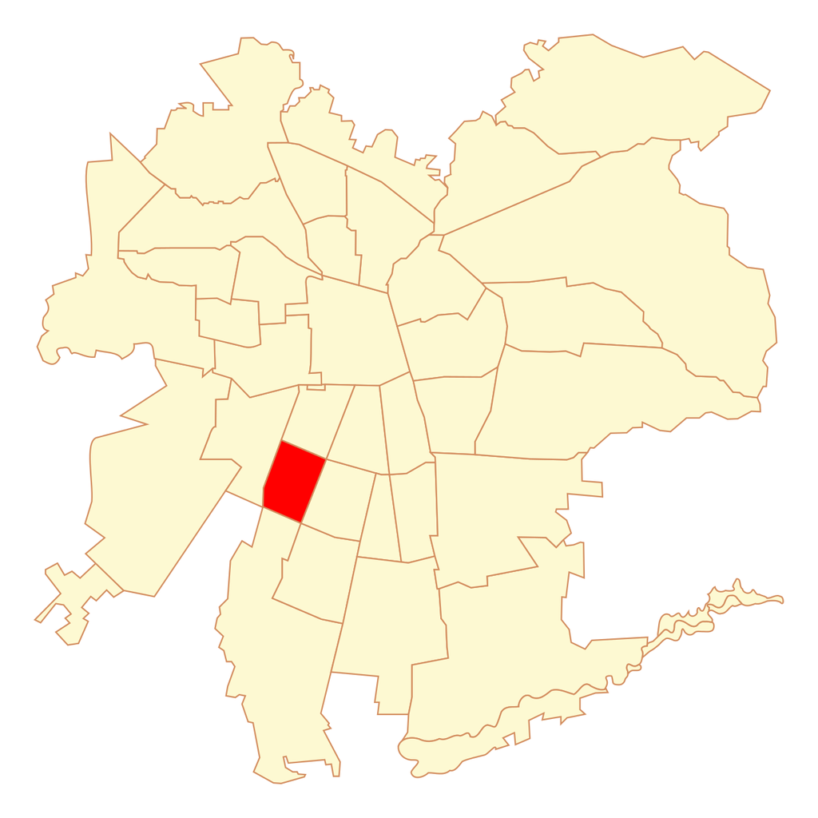

Escudo comunal

Lo Espejo

🏛️ Informe comunal · Red educativa

Comuna de Lo Espejo

SLEP Santa Rosa

Director ejecutivo

Luis Echeverría Donaire

Actualización

05-10-2026

Territorio

Lo Espejo

[🌐 slepsantarosa.gob.cl](https://slepsantarosa.gob.cl)[👥 ¿Quiénes somos?](https://slepsantarosa.gob.cl/quienes-somos/)[📰 Noticias](https://slepsantarosa.gob.cl/noticias/)

📍

Dirección

Llano Subercaseaux 3629  
San Miguel, SantiagoAbrir Google Maps ↗

🕘

Horario de atención

Lunes a viernes  
9:00 a 13:00 hrs.

✉️

Contacto general

contacto@slepsantarosa.gob.cl

📨

Oficina de partes

oficinapartes@slepsantarosa.gob.cl

**🗺️ Apertura territorial:** La siguiente sección es el mapa comunal integrado con zoom inicial reforzado, para ubicar la red antes del análisis temático.

🔎 Zoom inicial comunal

🏛

Municipalidad y autoridades

Municipalidad de Lo Espejo

Autoridades comunales 2024 - 2028 y enlaces institucionales de referencia

[🌐 Sitio web](https://www.loespejo.cl/)

Datos institucionales

🏠

Dirección municipal

Av. Lo Espejo 475, Lo Espejo

🌐

Sitio web

https://www.loespejo.cl/

🏫

Pdte. comisión educación

Por confirmar con municipalidad

Alcalde / alcaldesa

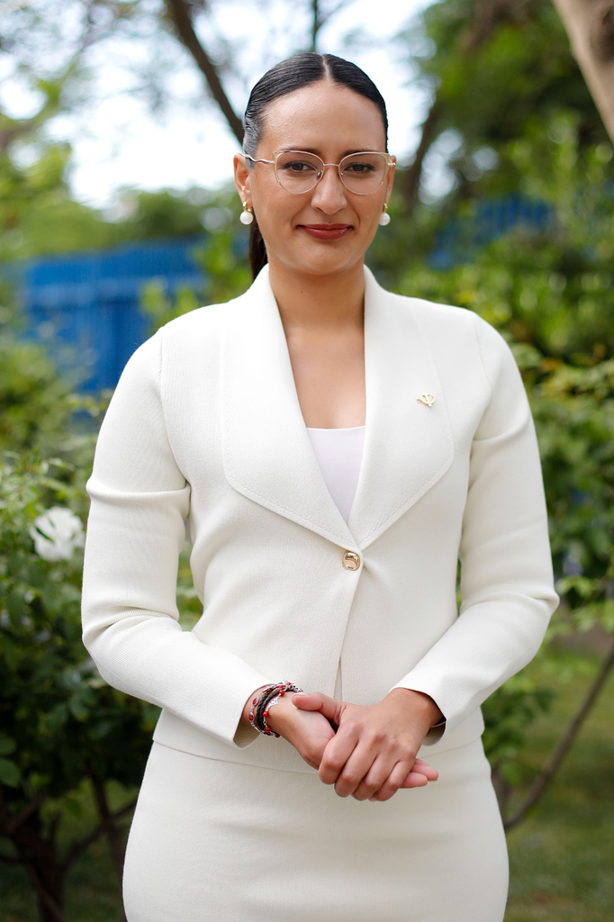

Javiera Paz Reyes Jara

(PC)

👥 Concejo municipal

8 concejales/as registrados

Carolina Haydée Sagredo Ugarte

(Ind.)

Elizabeth Henríquez Leiva

(Ind.)

Francisca Paz Ganga Zúñiga

(Ind.)

Javiera Paz López Layana

(Ind.)

Cecilia Benavides León

(Ind.)

Miguel Ángel Cerda Lucero

(Ind.)

Carlo Esteban Acosta de la Fuente

(Ind.)

Lorena Galleguillos Oliva

(Ind.)

🗺️ Red comunal

Mapa integrado de establecimientos y municipio · Comuna de Lo Espejo

Esta visualización ubica en un solo mapa a **escuelas y liceos**, **jardines infantiles** y la **municipalidad**. Al hacer clic en cada punto se abre una ficha breve con foco en matrícula y asistencia.

📍 27 puntos visibles

🏫 Escuelas y liceos

15

Asistencia ref.: Agosto 2026

🌱 Jardines infantiles

11

Corte ref.: Agosto 2026

📚 Matrícula total red

4.520

escuelas + jardines

🧭 Asistencia referencial

E/L 82.7% · JI 83.3%

promedio ponderado por matrícula

**Lectura del mapa:** 🏫 azul para escuelas y liceos, 🌱 lila para jardines infantiles y 🏛️ ámbar para la municipalidad. Los popups territoriales privilegian la lectura de matrícula y asistencia, manteniendo una referencia resumida de oferta educativa.  
Nota: el punto municipal se ubicó como referencia territorial cuando la base no trajo coordenadas explícitas.

[interactive chart not shown]

# 🗺️ Red Territorial

🗺️

Lectura territorial comunal

La portada ya deja el contexto institucional y comunal. Ahora el mapa abre la lectura espacial de **escuelas, liceos, jardines infantiles y municipio** para entrar después al detalle temático del informe.

📊

Panorama General · Comuna de Lo Espejo

Datos actualizados a Agosto 2026

🔄

**Cobertura del panorama comunal** 🏫 Escuelas y liceos 🌱 Jardines infantiles

En esta sección se mostrará la información consolidada de las escuelas, liceos y jardines infantiles de la comuna de Lo Espejo, integrando ambas redes en una lectura territorial con la paleta institucional del SLEP Santa Rosa.

Red educativa total

(Escuelas/Liceos + Jardines Infantiles)

📊 Matrícula Total

4.520

estudiantes + párvulos

🏫 Establecimientos

26

escuelas, liceos y jardines

📈 Promedio por EE

174

matrícula por establecimiento

🏫 Escuelas y Liceos

3.977

15 establecimientos · 88% del total

🌱 Jardines Infantiles

543

11 jardines · 12% del total

🏫 Escuelas y Liceos

(Agosto 2026)

👨‍🎓 Matrícula EyL

3.977

estudiantes activos

🏫 Establecimientos

15

escuelas y liceos

🗓️ Asistencia Promedio

82.7%

días asistidos/matriculados

🌱 Jardines Infantiles

(Agosto 2026)

👶 Matrícula JI

543

párvulos activos

🌿 Jardines

11

unidades del servicio

📅 Asistencia Promedio

83.3%

días asistidos/matriculados

Composición de matrícula por nivel

Escuelas, liceos y jardines infantiles de la comuna

Jardines Infantiles

🌱

Nivel Medio

376

párvulos

8.4%

8 jardines

Jardines Infantiles

🍼

Sala Cuna

121

párvulos

2.7%

6 jardines

Jardines Infantiles

🌟

Transición

16

párvulos

0.4%

1 jardines

Escuelas y Liceos

📚

Básica Niños

2.502

estudiantes

55.7%

13 establecimientos

Escuelas y Liceos

⚛️

Media HC Jóvenes

407

estudiantes

9.1%

3 establecimientos

Escuelas y Liceos

🏫

Parvularia

405

estudiantes

9%

13 establecimientos

Escuelas y Liceos

📖

Media HC Adultos

338

estudiantes

7.5%

3 establecimientos

Escuelas y Liceos

🛠️

Media TP Jóvenes

148

estudiantes

3.3%

2 establecimientos

Escuelas y Liceos

🧩

Ed. Especial

115

estudiantes

2.6%

1 establecimientos

Escuelas y Liceos

🌙

Básica Adultos

62

estudiantes

1.4%

2 establecimientos

**📅 Corte vigente:** Agosto 2026. La matrícula presentada en esta tabla proviene de la **tabla consolidada de matrícula y asistencia**.

### 🏫 Establecimientos de Comuna de Lo Espejo

15 establecimientos con matrícula activa

| Logo | Establecimiento | Director(a) | Comuna | Matrícula | Niveles | IVE EE 2026 | IVE Com. 2026 | SNCAE |
| --- | --- | --- | --- | --- | --- | --- | --- | --- |
|  | Liceo Teniente Francisco Mery Aguirre RBD 9726 | Héctor Andres Hormazabal Soto | Lo Espejo | 611 | 🏫 Parvularia · 🌙 Básica Adultos · 📚 Básica Niños · 📖 Media HC Adultos · ⚛️ Media HC Jóvenes | – | – | 🌿 Básico |
|  | Liceo Polivalente Lo Espejo RBD 9697 | José Cristian Gutierrez Lillo | Lo Espejo | 381 | 🏫 Parvularia · 📚 Básica Niños · 📖 Media HC Adultos · ⚛️ Media HC Jóvenes · 🛠️ Media TP Jóvenes | – | – | 🌿 Básico |
|  | Colegio Hernan Olguin RBD 9720 | Álex Ramon Alvarez Muñoz | Lo Espejo | 375 | 🏫 Parvularia · 📚 Básica Niños | – | – | Sin certificación |
|  | Centro Duc.cardenal Jose Maria Caro RBD 9690 | Matias Jesus Aranguiz Lopez | Lo Espejo | 356 | 🌙 Básica Adultos · 📖 Media HC Adultos · ⚛️ Media HC Jóvenes · 🛠️ Media TP Jóvenes | – | – | Sin certificación |
|  | Escuela Basica Clara Estrella RBD 9733 | Sebastian Alejandro Valenzuela Cabezas | Lo Espejo | 264 | 🏫 Parvularia · 📚 Básica Niños | – | – | 🌿 Básico |
|  | Escuela Raul Saez Saez RBD 9734 | Cecilia Del Pilar Cumican Martinez | Lo Espejo | 252 | 🏫 Parvularia · 📚 Básica Niños | – | – | Sin certificación |
|  | Escuela Básica Santa Olga De Kiev RBD 9719 | Jaime Antonio Cornejo Jiménez (s) | Lo Espejo | 233 | 🏫 Parvularia · 📚 Básica Niños | – | – | 🌿 Excelencia |
|  | Escuela Basica Bernardo O´Higgins RBD 9736 | Francisco Javier Rebolledo Orellana | Lo Espejo | 229 | 🏫 Parvularia · 📚 Básica Niños | – | – | 🌿 Básico |
|  | Escuela Basica República De Indonesia RBD 9741 | Martín Ignacio Guevara Araneda | Lo Espejo | 229 | 🏫 Parvularia · 📚 Básica Niños | – | – | Sin certificación |
|  | Escuela Blue Star College RBD 9709 | ELIANA FLORENTINA ESTEBAN MORALES | Lo Espejo | 206 | 🏫 Parvularia · 📚 Básica Niños | – | – | Sin certificación |
|  | Escuela Basica República De Las Filipinas RBD 9740 | Daniel Alejandro Maturana Claveria | Lo Espejo | 199 | 🏫 Parvularia · 📚 Básica Niños | – | – | Sin certificación |
|  | Escuela Basica Acapulco RBD 9716 | Patricia Angelica Mella Peñaloza | Lo Espejo | 197 | 🏫 Parvularia · 📚 Básica Niños | – | – | 🌿 Medio |
|  | Escuela Basica Salomon Sack RBD 9705 | David Bernardo Perez Romero | Lo Espejo | 181 | 🏫 Parvularia · 📚 Básica Niños | – | – | 🌿 Básico |
|  | Escuela Basica Santa Adriana RBD 9710 | Juan Pablo Orellana Martinez | Lo Espejo | 149 | 🏫 Parvularia · 📚 Básica Niños | – | – | 🌿 Básico |
|  | Escuela Especial De Educacion Tamarugal RBD 12103 | Denisse Alejandra Faundez Vergara | Lo Espejo | 115 | 🧩 Ed. Especial | – | – | Sin certificación |

### 🌱 Jardines Infantiles de Comuna de Lo Espejo

11 jardines filtrados por comuna

**📍 Fuente y filtro:** tabla de jardines del informe 04, filtrada para Lo Espejo. La matrícula corresponde al **último corte disponible** (Agosto 2026). Se muestra además la **directora** y los **niveles ofertados**.

| Logo | Jardín Infantil | Directora | Matrícula | Niveles |
| --- | --- | --- | --- | --- |
|  | Jardin Infantil Mi Mundo En Miniaturas RBD 13116014 | Mireya Del Carmen Belmar Gallardo | 93 | 👶 Sala Cuna · 🧒 Nivel Medio |
|  | Jardin Infantil Estrellitas De La Mañana RBD 13116009 | María Lorena Silva Ibarra | 80 | 👶 Sala Cuna · 🧒 Nivel Medio |
|  | Jardin Infantil Pequeños Gigantes RBD 13116010 | Johanna Ivonne Parada Reyes | 78 | 👶 Sala Cuna · 🧒 Nivel Medio |
|  | Jardin Infantil Mis Primeros Pasos RBD 13116011 | Rina Ximena Pradena Villa | 69 | 👶 Sala Cuna · 🧒 Nivel Medio |
|  | Jardin Infantil Huelemu RBD 13116015 | Natalia Soto Lizana | 66 | 👶 Sala Cuna · 🧒 Nivel Medio |
|  | Jardin Infantil Jesús Pescador RBD 13116026 | Ximena Beatriz Donoso Toro | 54 | 🧒 Nivel Medio · 🎒 Transición |
|  | Jardin Infantil Manitos De Colores RBD 13116016 | Susana Jacqueline Rebolledo Peña | 50 | 👶 Sala Cuna · 🧒 Nivel Medio |
|  | Jardin Infantil Cardenal Caro RBD 13116027 | María Carolina Margarita Pinochet Sánchez | 28 | 🧒 Nivel Medio |
|  | Jardin Infantil Santa Adriana RBD 13116028 | Verónica Irma Paredes Araneda | 25 | 🧒 Nivel Medio |
| JI | Jardin Infantil La Sonrisa RBD 13116025 | (Cerrado con convenio vigente) | 0 | 👶 Sala Cuna · 🧒 Nivel Medio |
| JI | Jardin Infantil Renacer Por Un Sueño RBD 13116024 | – | 0 | 👶 Sala Cuna · 🧒 Nivel Medio |

📊

Datos complementarios al desempeño académico

Indicadores de contexto escolar

SNCAE

Sistema Nacional de Certificación Ambiental

Ministerio de Medio Ambiente

Indicador institucional que muestra si el establecimiento participa en el sistema de certificación ambiental y el **nivel alcanzado** . Su lectura es cualitativa: permite distinguir el grado de avance en educación ambiental, gestión sustentable y trabajo con la comunidad.

Cómo leerlo en la ficha Sin certificación o nivel alcanzado

Participación Voluntaria

Tipo de dato Cualitativo

Básico Medio Excelencia

IVE-JUNAEB

Índice de Vulnerabilidad Escolar

JUNAEB

Indicador que estima el porcentaje de estudiantes en situación de **vulnerabilidad socioeducativa** . Se expresa entre 0% y 100%: a mayor valor, mayor concentración de estudiantes con prioridad social. En esta edición se presenta el **IVE SINAE 2026 del establecimiento** junto con su **referencia comunal 2026** .

Escala 0% — 100%

Cómo leerlo en la ficha Mayor porcentaje = mayor vulnerabilidad; comparar con referencia comunal

Versiones IVE establecimiento 2026 + IVE comunal 2026

IVE EE 2026 IVE Comunal 2026 Serie metodológica vigente

SNED

Sistema Nacional de Evaluación del Desempeño

Desempeño de excelencia

Indicador que identifica establecimientos con **desempeño de excelencia** dentro de grupos comparables. En la ficha se interpreta de forma binaria: el establecimiento **obtuvo o no obtuvo SNED** en el proceso vigente.

Cómo leerlo en la ficha Sí obtuvo o no obtuvo SNED

Periodicidad Proceso bianual

Comparación Entre establecimientos semejantes

Tipo de dato Binario

Resultado binario Desempeño de excelencia Comparación entre pares

# 🌿 Certificación Ambiental SNCAE

# 📈 IVE SINAE 2026 y referencia comunal

#### 🌿 Certificación Ambiental SNCAE

Con Certificación

8

(53.3% del total)

Sin Certificación

7

##### 📋 Establecimientos con Certificación SNCAE

| Logo | RBD | Establecimiento | Comuna | Nivel SNCAE |
| --- | --- | --- | --- | --- |
|  | 9697 | Liceo Polivalente Lo Espejo | Lo Espejo | Básico |
|  | 9705 | Escuela Basica Salomon Sack | Lo Espejo | Básico |
|  | 9710 | Escuela Basica Santa Adriana | Lo Espejo | Básico |
|  | 9716 | Escuela Basica Acapulco | Lo Espejo | Medio |
|  | 9719 | Escuela Básica Santa Olga De Kiev | Lo Espejo | Excelencia |
|  | 9726 | Liceo Teniente Francisco Mery Aguirre | Lo Espejo | Básico |
|  | 9733 | Escuela Basica Clara Estrella | Lo Espejo | Básico |
|  | 9736 | Escuela Basica Bernardo O´Higgins | Lo Espejo | Básico |

#### 📈 IVE SINAE 2026 y referencia comunal

El análisis se construye con el IVE SINAE 2026 disponible para cada establecimiento y su referencia comunal vigente. La lectura se presenta según la serie metodológica actual.

IVE promedio EE

–

0 establecimientos con dato

IVE comunal 2026

–

0 comunas

IVE EE sobre 80

0

0% de los establecimientos con dato

Sobre ref. comunal

0

0% de los EE comparables

##### 🏫 IVE establecimiento 2026

| Tramo | N° EE | % |
| --- | --- | --- |
| 0-20% | 0 | 0,0% |
| 21-40% | 0 | 0,0% |
| 41-60% | 0 | 0,0% |
| 61-80% | 0 | 0,0% |
| 81-100% | 0 | 0,0% |

##### 🏙️ Referencia comunal 2026

| Comuna | IVE comunal | N° EE |
| --- | --- | --- |
| Sin referencias comunales disponibles. |  |  |

La referencia comunal se informa con la base 2026 vigente para cada territorio. Esta sección reemplaza la lectura histórica basada en aperturas metodológicas anteriores.

# 🏆 SNED

### 🏆 Sistema Nacional de Evaluación del Desempeño (SNED) - Comuna de Lo Espejo

El **SNED** es un instrumento de política pública del Estado de Chile que evalúa y reconoce el desempeño de los establecimientos educacionales en función de múltiples indicadores de calidad y equidad educativa. Considera dimensiones como la efectividad, superación, iniciativa, mejoramiento, igualdad e integración. Los establecimientos con mejor desempeño relativo acceden a la **Subvención por Desempeño de Excelencia**.

Participan en SNED

15

de 15 establecimientos

🏆 Seleccionados

1

Subvención de Excelencia

No Seleccionados

14

Índice SNED Promedio

60.75

Promedio SLEP

##### 🏆 Establecimientos Seleccionados - Subvención de Excelencia

RBD 9733

Escuela Basica Clara Estrella

Lo Espejo

Índice

66.25

##### 📊 Desglose de Factores - Promedio SLEP

Efectividad37%

Mide el nivel de resultados educativos alcanzados, considerando el desempeño en pruebas SIMCE.

28.6%

📋 14 establecimientos con datos

Superación28%

Evalúa los avances en resultados educativos a lo largo del tiempo.

64.8%

📋 14 establecimientos con datos

Iniciativa6%

Considera la capacidad para innovar y fortalecer el proyecto educativo.

84.1%

📋 15 establecimientos con datos

Mejoramiento2%

Evalúa el cumplimiento normativo y funcionamiento institucional.

96.7%

📋 15 establecimientos con datos

Integración5%

Evalúa la participación de la comunidad educativa.

73.3%

📋 15 establecimientos con datos

Igualdad22%

Mide el grado de inclusión e igualdad de oportunidades.

91.6%

📋 15 establecimientos con datos

# 🧑‍🎓 Concentración alumnos prioritarios

### 📊 Concentración · Alumnado Prioritario

2025 · Promedio Comuna

69.8%

2026 · Promedio Comuna

66.4%

Variación Promedio

↓ 3.4 pp

Comparación 2026 vs 2025

| Logo | RBD | Establecimiento | 2025 Concentración | 2026 Concentración | Variación |
| --- | --- | --- | --- | --- | --- |
|  | 12103 | ESCUELA ESPECIAL TAMARUGAL EX 355 📅 Marzo Mantienen ACAP | 78.5% | 79% | ↑ +0.5 pp |
|  | 9719 | ESCUELA BASICA ALICIA ARIZTÍA DE SILVA 📅 Marzo Mantienen ACAP | 77.1% | 78.7% | ↑ +1.6 pp |
|  | 9741 | ESCUELA REPÚBLICA DE INDONESIA EX 587 📅 Marzo Mantienen ACAP | 75.6% | 76.3% | ↑ +0.7 pp |
|  | 9716 | ESCUELA BASICA ACAPULCO 📅 Marzo Mantienen ACAP | 79.2% | 74.6% | ↓ 4.5 pp |
|  | 9720 | COLEGIO HERNAN OLGUIN 📅 Marzo Mantienen ACAP | 77% | 73.2% | ↓ 3.8 pp |
|  | 9740 | ESCUELA BASICA REPUBLICA DE LAS FILIPINAS 📅 Marzo Mantienen ACAP | 74.9% | 72.1% | ↓ 2.9 pp |
|  | 9705 | ESCUELA BASICA SALOMON SACK 📅 Marzo Mantienen ACAP | 73.6% | 70.1% | ↓ 3.4 pp |
|  | 9733 | ESCUELA BASICA CLARA ESTRELLA 📅 Marzo Mantienen ACAP | 76.8% | 68.6% | ↓ 8.2 pp |
|  | 9710 | ESCUELA BASICA SANTA ADRIANA 📅 Marzo Mantienen ACAP | 67.3% | 65.2% | ↓ 2.2 pp |
|  | 9736 | ESCUELA BASICA BERNARDO O´HIGGINS 📅 Marzo Mantienen ACAP | 70.5% | 64.4% | ↓ 6.1 pp |
|  | 9734 | ESCUELA RAUL SAEZ SAEZ 📅 Marzo Mantienen ACAP | 68.3% | 63.2% | ↓ 5.1 pp |
|  | 9709 | ESCUELA BLUE STAR COLLEGE 📅 Marzo Mantienen ACAP | 62.1% | 60.4% | ↓ 1.7 pp |
|  | 9697 | LICEO POLIVALENTE EX 133 📅 Marzo Pierde ACAP en 2026 | 64.8% | 55.8% | ↓ 9 pp |
|  | 9726 | LICEO TENIENTE FRANCISCO MERY AGUIRRE 📅 Marzo Sin ACAP 2025-2026 | 53.6% | 49.7% | ↓ 3.8 pp |
|  | 9690 | CENTRO DUC.CARDENAL JOSE MARIA CARO 📅 Marzo Sin ACAP 2025-2026 | 47.7% | 43.8% | ↓ 3.9 pp |

ℹ️ Lectura de la tabla:↑ Aumento en concentración de alumnado prioritario | ↓ Disminución en concentración | 2025 vs 2026

### 🛠️ Establecimientos Técnico-Profesionales

2

Establecimientos TP

Matrícula Total TP

Establecimientos que imparten educación Media Técnico-Profesional con diversas especialidades según demanda territorial y proyecto educativo.

| Logo | RBD | Establecimiento | Comuna | Matrícula | Especialidades |
| --- | --- | --- | --- | --- | --- |
|  | 9690 | Centro Duc.cardenal Jose Maria Caro | Lo Espejo | 338 | 📂 Administración (mención)🚗 Mecánica Automotriz |
|  | 9697 | Liceo Polivalente Lo Espejo | Lo Espejo | 395 | 📶 Telecomunicaciones👶 Atención Párvulos |

##### 📋 Resumen de Especialidades Impartidas en el SLEP

**4** especialidades distintas impartidas en **2** establecimientos TP.

📂 Administración (mención)1 EE

🚗 Mecánica Automotriz1 EE

📶 Telecomunicaciones1 EE

👶 Atención Párvulos1 EE

# 🏫 Resumen Matrícula

📊 Sección

Detalle de Matrícula · Comuna de Lo Espejo

Escuelas, liceos y jardines infantiles de la red comunal

📍 Vista comunal integrada

La **matrícula** corresponde al registro de niños, niñas y estudiantes vigentes en cada establecimiento del territorio. En esta sección se presentan de manera complementaria los detalles de matrícula de **escuelas y liceos** y de **jardines infantiles** de la comuna de Lo Espejo. La lectura integrada permite comparar volumen, distribución por establecimiento y composición por nivel educativo dentro de la red comunal del **SLEP Santa Rosa**.

🏫Escuelas y Liceos

▸Fuente principal: **CEM · SIGE · Mineduc** vía DEP.

▸Corte de referencia: **Agosto 2026**.

▸Se desagrega por establecimiento, género, nacionalidad, pueblos originarios, grado y nivel educativo.

🌱Jardines Infantiles

▸Fuente principal: **Gesparvu / GPW JUNJI** consolidada en el informe comunal.

▸Corte de referencia: **Agosto 2026**.

▸Se muestra matrícula por jardín, distribución por Sala Cuna, Nivel Medio y Transición, junto con asistencia y capacidad cuando existen datos.

🧭Cómo leer esta sección

▸Primero se presenta el **detalle de escuelas y liceos** con su composición de matrícula y variables sociodemográficas.

▸Luego se presenta el **detalle de jardines infantiles**, con foco en volumen de párvulos, niveles ofertados y desempeño del corte vigente.

📊 Panorama consolidado

Matrícula de escuelas y liceos

Información agregada de los establecimientos de la comuna de Lo Espejo. **Fuente:** Centro de Estudios del Mineduc (CEM).

📅 Datos a: Agosto 2026🔄 Actualización mensual

👥

##### Resumen matrícula

Total estudiantes

3.977

📅 Agosto 2026

👥

🏫 Establecimientos activos**15**

🌍 Estudiantes extranjeros**1.025 (25,8%)**

🌎

##### Composición

Género

👦 Masculino**2.083** (52,4%)

👧 Femenino**1.894** (47,6%)

Origen

🇨🇱 Chilenos**2.952** (74,2%)

🌍 Extranjeros**1.025** (25,8%)

🌿

##### Pueblos originarios

🌿 Mapuche**152** (3,8%)

🌐 Otra etnia**24** (0,6%)

☀️ Aymara**2** (0,1%)

🏺 Diaguita**2** (0,1%)

🏔️ Quechua**1** (0,0%)

🗺️

##### Nacionalidades

🇨🇱 Chilena**3.056** (76,8%)

🇻🇪 Venezolana**250** (6,3%)

🌐 Otra**233** (5,9%)

🇭🇹 Haitiana**143** (3,6%)

🇨🇴 Colombiana**54** (1,4%)

🇪🇨 Ecuatoriana**42** (1,1%)

🇵🇪 Peruana**29** (0,7%)

🇧🇴 Boliviana**22** (0,6%)

🇦🇷 Argentina**6** (0,2%)

🇩🇴 Dominicana**6** (0,2%)

🇧🇷 Brasilera**3** (0,1%)

🇺🇸 Estadounidense**1** (0,0%)

🇲🇽 Mexicana**1** (0,0%)

📊

##### Matrícula por nivel

🏫 Parvularia**405** (10,2%)

📚 Básica Niños**2.502** (62,9%)

⚛️ Media HC Jóvenes**407** (10,2%)

🛠️ Media TP Jóvenes**148** (3,7%)

🧩 Ed. Especial**115** (2,9%)

🌙 Básica Adultos**62** (1,6%)

📖 Media HC Adultos**338** (8,5%)

🛠️

##### Matrícula TP por especialidad

📂 Administración**45** (1,1%)

🚗 Mecánica Automotriz**38** (1,0%)

👶 Atención de párvulos**35** (0,9%)

📡 Telecomunicaciones**30** (0,8%)

🎓

##### Detalle por curso

Distribución total de estudiantes por curso o grado en el último período disponible.

Pre-kínder**186** (4,7%)

Kínder**219** (5,5%)

1° Básico**269** (6,8%)

2° Básico**316** (7,9%)

3° Básico**352** (8,9%)

4° Básico**279** (7,0%)

5° Básico**367** (9,2%)

6° Básico**335** (8,4%)

7° Básico**326** (8,2%)

8° Básico**337** (8,5%)

1° Medio**165** (4,1%)

2° Medio**159** (4,0%)

3° Medio**140** (3,5%)

4° Medio**91** (2,3%)

Nivel de Transición 2**8** (0,2%)

Laboral 1**14** (0,4%)

Laboral 2**14** (0,4%)

Nivel Básico 3 (7° y 8° Básico)**62** (1,6%)

1° Nivel (Adultos)**125** (3,1%)

2° Nivel (Adultos)**213** (5,4%)

##### 🏫 Detalle de Matrícula por Establecimiento

Desglose completo de 15 establecimientos con matrícula activa.

| Logo | Establecimiento | 📊 Matrícula Total | 👥 Género 👨 M | 👥 Género 👩 F | 🌎 Nacionalidad 🏔️ Chi | 🌎 Nacionalidad 🌍 Ext | 🌎 Nacionalidad 📄 Nac | 🌿 Pueblos Orig. N° |
| --- | --- | --- | --- | --- | --- | --- | --- | --- |
|  | Liceo Teniente Francisco Mery Aguirre RBD 9726 | 611 15,4% | 310 | 301 | 373 | 238 (39,0%) | 0 | 27 (4,4%) |
|  | Liceo Polivalente Lo Espejo RBD 9697 | 381 9,6% | 199 | 182 | 263 | 118 (31,0%) | 0 | 10 |
|  | Colegio Hernan Olguin RBD 9720 | 375 9,4% | 207 | 168 | 305 | 70 (18,7%) | 0 | 43 (11,5%) |
|  | Centro Duc.cardenal Jose Maria Caro RBD 9690 | 356 9,0% | 184 | 172 | 204 | 152 (42,7%) | 0 | 21 (5,9%) |
|  | Escuela Basica Clara Estrella RBD 9733 | 264 6,6% | 137 | 127 | 221 | 43 (16,3%) | 0 | 10 (3,8%) |
|  | Escuela Raul Saez Saez RBD 9734 | 252 6,3% | 139 | 113 | 184 | 68 (27,0%) | 0 | 9 (3,6%) |
|  | Escuela Básica Santa Olga De Kiev RBD 9719 | 233 5,9% | 121 | 112 | 202 | 31 (13,3%) | 0 | 6 |
|  | Escuela Basica Bernardo O´Higgins RBD 9736 | 229 5,8% | 105 | 124 | 170 | 59 (25,8%) | 0 | 6 |
|  | Escuela Basica República De Indonesia RBD 9741 | 229 5,8% | 111 | 118 | 173 | 56 (24,5%) | 0 | 7 (3,1%) |
|  | Escuela Blue Star College RBD 9709 | 206 5,2% | 112 | 94 | 159 | 47 (22,8%) | 0 | 8 (3,9%) |
|  | Escuela Basica República De Las Filipinas RBD 9740 | 199 5,0% | 91 | 108 | 157 | 42 (21,1%) | 0 | 11 (5,5%) |
|  | Escuela Basica Acapulco RBD 9716 | 197 5,0% | 109 | 88 | 166 | 31 (15,7%) | 0 | 8 (4,1%) |
|  | Escuela Basica Salomon Sack RBD 9705 | 181 4,6% | 91 | 90 | 154 | 27 (14,9%) | 0 | 8 (4,4%) |
|  | Escuela Basica Santa Adriana RBD 9710 | 149 3,7% | 87 | 62 | 115 | 34 (22,8%) | 0 | 4 |
|  | Escuela Especial De Educacion Tamarugal RBD 12103 | 115 2,9% | 80 | 35 | 106 | 9 (7,8%) | 0 | 3 |
| TOTAL COMUNA |  | 3.977 | 2.083 | 1.894 | 2.952 | 1.025 | 0 | 181 |

👶

Jardines Infantiles

Detalle de Matrícula de Jardines — Comuna de Lo Espejo

Gesparvu / GPW JUNJI · Corte vigente: Agosto 2026

11 jardines filtrados

📅 Corte

Agosto 2026

👶 Matrícula del corte

543

párvulos activos

🏡 Jardines con matrícula

9

unidades con movimiento

🚻 Matrícula por género

👦 Masculino**265 (53%)**

👧 Femenino**235 (47%)**

🧭 Asistencia agregada

83.3%

días asistidos / matriculados

Sala Cuna

121

párvulos

22.3%

6 jardines

Nivel Medio

376

párvulos

69.2%

8 jardines

Transicion

16

párvulos

2.9%

1 jardines

Grado 11

30

párvulos

5.5%

1 jardines

##### 🏫 Detalle de Matrícula por Jardín Infantil

Desglose completo de 9 jardines con matrícula activa en el corte seleccionado.

| Logo | Jardín Infantil | 📊 Matrícula Total | 🍼 Niveles del corte 👶 Sala Cuna | 🍼 Niveles del corte 🧒 Nivel Medio | 🍼 Niveles del corte 🎒 Transición | 🧭 Asistencia % |
| --- | --- | --- | --- | --- | --- | --- |
|  | Jardin Infantil Mi Mundo En Miniaturas RBD 13116014 👩‍🏫 Mireya Del Carmen Belmar Gallardo | 93 17.1% | 29 (31.2%) | 64 (68.8%) | 0 | 82.2% cap. 98 |
|  | Jardin Infantil Estrellitas De La Mañana RBD 13116009 👩‍🏫 María Lorena Silva Ibarra | 80 14.7% | 19 (23.8%) | 61 (76.2%) | 0 | 88% cap. 84 |
|  | Jardin Infantil Pequeños Gigantes RBD 13116010 👩‍🏫 Johanna Ivonne Parada Reyes | 78 14.4% | 18 (23.1%) | 60 (76.9%) | 0 | 86.8% cap. 84 |
|  | Jardin Infantil Mis Primeros Pasos RBD 13116011 👩‍🏫 Rina Ximena Pradena Villa | 69 12.7% | 17 (24.6%) | 52 (75.4%) | 0 | 85.4% cap. 84 |
|  | Jardin Infantil Huelemu RBD 13116015 👩‍🏫 Natalia Soto Lizana | 66 12.2% | 18 (27.3%) | 48 (72.7%) | 0 | 85.2% cap. 80 |
|  | Jardin Infantil Jesús Pescador RBD 13116026 👩‍🏫 Ximena Beatriz Donoso Toro | 54 9.9% | 0 | 38 (70.4%) | 16 (29.6%) | 82.7% cap. 55 |
|  | Jardin Infantil Manitos De Colores RBD 13116016 👩‍🏫 Susana Jacqueline Rebolledo Peña | 50 9.2% | 20 (40%) | 0 | 0 | 75.2% cap. 52 |
|  | Jardin Infantil Cardenal Caro RBD 13116027 👩‍🏫 María Carolina Margarita Pinochet Sánchez | 28 5.2% | 0 | 28 (100%) | 0 | 82% cap. 35 |
|  | Jardin Infantil Santa Adriana RBD 13116028 👩‍🏫 Verónica Irma Paredes Araneda | 25 4.6% | 0 | 25 (100%) | 0 | 68.4% cap. 42 |
| TOTAL COMUNA |  | 543 | 121 | 376 | 16 | 81.8% |

# 🕰️ Evolución Matricula

🕰️ Sección

Evolución Histórica de la Matrícula

CEM · SIGE · Serie histórica anual

📈 Tendencia Histórica

La **evolución histórica de matrícula** muestra cómo ha variado el número de estudiantes inscritos a lo largo de los años en los establecimientos de la comuna de Lo Espejo. Esta tendencia es un indicador estructural del territorio: refleja cambios demográficos, migraciones, decisiones de familias sobre el tipo de educación y el impacto de políticas públicas como la **Ley SEP (Subvención Escolar Preferencial)** o las campañas de permanencia escolar. Un descenso sostenido de matrícula en el sector público puede indicar un proceso de **“fuga” hacia el sector subvencionado**, lo que requiere análisis territorial.

📊Cómo leer la tendencia

▸Se compara el **promedio mensual de matrícula de cada año**, resumiendo la serie consolidada disponible.

▸**Variación % interanual:** caídas de más de 3% en un año son señal de alerta para la gestión territorial.

🌐Factores que afectan la matrícula

▸**Demográficos:** tasas de natalidad, migraciones internas, densificación urbana.

▸**Elección de familias:** oferta de establecimientos privados subvencionados en el territorio.

## 📈 Evolución Histórica de la Matrícula de Escuelas y Liceos - Comuna de Lo Espejo

#### 📊 Panel de Análisis Histórico

Visualización del **promedio anual de matrícula** construido desde la serie mensual consolidada. **Fuente:** Centro de Estudios del Mineduc (CEM).

📅 Último Año

2026

👨‍🎓 Matrícula Promedio

3.979

Promedio mensual del año

📊 Var. Interanual

-3.6%

🏫 Estab. Promedio

15

6 meses considerados

[interactive chart not shown]

##### 🏫 Matrícula Promedio por Establecimiento y Año

Comparativa anual de matrícula promedio por establecimiento. **Nota:** La variación porcentual (Var.) se calcula comparando el promedio de matrícula del año **2026** respecto al promedio del año **2025**.

| Logo | RBD | Establecimiento | Comuna | 2016 | 2017 | 2018 | 2019 | 2022 | 2023 | 2024 | 2025 | 2026 | Var. % |
| --- | --- | --- | --- | --- | --- | --- | --- | --- | --- | --- | --- | --- | --- |
|  | 9726 | Liceo Teniente Francisco Mery Aguirre | Lo Espejo | 368 | 466 | 584 | 621 | 628 | 532 | 538 | 597 | 610 | +2.2% |
|  | 9720 | Colegio Hernan Olguin | Lo Espejo | 880 | 846 | 838 | 857 | 670 | 600 | 483 | 452 | 386 | -14.6% |
|  | 9697 | Liceo Polivalente Lo Espejo | Lo Espejo | 288 | 322 | 345 | 391 | 330 | 380 | 410 | 407 | 383 | -5.9% |
|  | 9690 | Centro Duc.cardenal Jose Maria Caro | Lo Espejo | 251 | 258 | 313 | 344 | 266 | 220 | 272 | 334 | 352 | +5.4% |
|  | 9733 | Escuela Basica Clara Estrella | Lo Espejo | 354 | 319 | 311 | 302 | 301 | 309 | 294 | 280 | 264 | -5.7% |
|  | 9734 | Escuela Raul Saez Saez | Lo Espejo | 194 | 162 | 186 | 210 | 269 | 272 | 282 | 270 | 251 | -7% |
|  | 9719 | Escuela Básica Santa Olga De Kiev | Lo Espejo | 312 | 315 | 314 | 308 | 270 | 247 | 244 | 237 | 230 | -3% |
|  | 9736 | Escuela Basica Bernardo O´Higgins | Lo Espejo | 320 | 348 | 339 | 300 | 280 | 234 | 231 | 252 | 230 | -8.7% |
|  | 9741 | Escuela Basica República De Indonesia | Lo Espejo | 335 | 319 | 302 | 306 | 283 | 262 | 249 | 239 | 219 | -8.4% |
|  | 9709 | Escuela Blue Star College | Lo Espejo | 180 | 154 | 146 | 157 | 151 | 185 | 180 | 184 | 200 | +8.7% |
|  | 9716 | Escuela Basica Acapulco | Lo Espejo | 333 | 297 | 280 | 288 | 218 | 204 | 197 | 208 | 200 | -3.8% |
|  | 9740 | Escuela Basica República De Las Filipinas | Lo Espejo | 178 | 204 | 235 | 243 | 214 | 212 | 219 | 209 | 197 | -5.7% |
|  | 9705 | Escuela Basica Salomon Sack | Lo Espejo | 234 | 256 | 257 | 233 | 199 | 199 | 205 | 197 | 184 | -6.6% |
|  | 9710 | Escuela Basica Santa Adriana | Lo Espejo | 187 | 154 | 146 | 176 | 169 | 157 | 157 | 153 | 156 | +2% |
|  | 12103 | Escuela Especial De Educacion Tamarugal | Lo Espejo | 72 | 69 | 78 | 85 | 97 | 111 | 114 | 107 | 116 | +8.4% |

##### 📈 Top 10 Mayor Crecimiento (2025 → 2026)

1

Escuela Blue Star College

RBD 9709 • Lo Espejo

+8.7%

2

Escuela Especial De Educacion Tamarugal

RBD 12103 • Lo Espejo

+8.4%

3

Centro Duc.cardenal Jose Maria Caro

RBD 9690 • Lo Espejo

+5.4%

4

Liceo Teniente Francisco Mery Aguirre

RBD 9726 • Lo Espejo

+2.2%

5

Escuela Basica Santa Adriana

RBD 9710 • Lo Espejo

+2%

6

Escuela Básica Santa Olga De Kiev

RBD 9719 • Lo Espejo

+-3%

7

Escuela Basica Acapulco

RBD 9716 • Lo Espejo

+-3.8%

8

Escuela Basica Clara Estrella

RBD 9733 • Lo Espejo

+-5.7%

9

Escuela Basica República De Las Filipinas

RBD 9740 • Lo Espejo

+-5.7%

10

Liceo Polivalente Lo Espejo

RBD 9697 • Lo Espejo

+-5.9%

##### 📉 Top 10 Mayor Decrecimiento (2025 → 2026)

1

Colegio Hernan Olguin

RBD 9720 • Lo Espejo

-14.6%

2

Escuela Basica Bernardo O´Higgins

RBD 9736 • Lo Espejo

-8.7%

3

Escuela Basica República De Indonesia

RBD 9741 • Lo Espejo

-8.4%

4

Escuela Raul Saez Saez

RBD 9734 • Lo Espejo

-7%

5

Escuela Basica Salomon Sack

RBD 9705 • Lo Espejo

-6.6%

6

Liceo Polivalente Lo Espejo

RBD 9697 • Lo Espejo

-5.9%

7

Escuela Basica Clara Estrella

RBD 9733 • Lo Espejo

-5.7%

8

Escuela Basica República De Las Filipinas

RBD 9740 • Lo Espejo

-5.7%

9

Escuela Basica Acapulco

RBD 9716 • Lo Espejo

-3.8%

10

Escuela Básica Santa Olga De Kiev

RBD 9719 • Lo Espejo

-3%

🌱

Jardines Infantiles

Parte 2 · Jardines Infantiles — Evolución Histórica de Matrícula · Comuna de Lo Espejo

Gesparvu / GPW JUNJI · serie histórica comunal de párvulos matriculados

11 jardines filtrados

📊 Lectura histórica de jardines infantiles

Esta segunda parte presenta la **evolución histórica agregada de la matrícula en jardines infantiles** de la comuna de Lo Espejo. Se observan los cambios en el volumen de párvulos matriculados, la cantidad de jardines con registros vigentes y la composición promedio por nivel ofertado. **Fuente:** Gesparvu / GPW JUNJI.

📅 Último período

Agosto 2026

👶 Matrícula actual

543

párvulos matriculados

📈 Var. interanual

+4,2%

comparación con igual mes del año previo

🏡 Jardines observados

9

mejor registro: Diciembre 2025

Últimos 12 períodos observados · Jardines infantiles

| Período | Matrícula | Jardines | Var. período |
| --- | --- | --- | --- |
| Julio 2025 | 515 | 8 | +1,4% |
| Agosto 2025 | 521 | 8 | +1,2% |
| Septiembre 2025 | 530 | 8 | +1,7% |
| Octubre 2025 | 525 | 8 | -0,9% |
| Noviembre 2025 | 533 | 8 | +1,5% |
| Diciembre 2025 | 548 | 9 | +2,8% |
| Marzo 2026 | 498 | 9 | -9,1% |
| Abril 2026 | 524 | 9 | +5,2% |
| Mayo 2026 | 539 | 9 | +2,9% |
| Junio 2026 | 539 | 9 | +0,0% |
| Julio 2026 | 533 | 9 | -1,1% |
| Agosto 2026 | 543 | 9 | +1,9% |

# 🏫 Resumen asistencia

🧭 Sección

Evolución Histórica de Asistencia

SIGE · Ley SAE · Ausentismo crónico

📅 Ley SAE

La **asistencia escolar** mide qué porcentaje de los días hábiles en que un estudiante tenía matrícula vigente, efectivamente asistió al establecimiento. Se calcula como: **días asistidos ÷ días con matrícula activa × 100**. La **Ley SAE (Sistema de Alerta Escolar)** obliga a los establecimientos a reportar y gestionar el ausentismo. El **ausentismo crónico** se define como la inasistencia a más del 20% de los días hábiles y es un predictor fuerte de rezago, repitencia y abandono escolar.

⚠️Umbrales de alerta

▸**≥ 90%:** asistencia regular. Meta mínima del sistema.

▸**80–89%:** riesgo moderado. Requiere seguimiento individual.

▸**< 80%:** ausentismo crónico. Activación de protocolo SAE y reporte a la DEP.

💡Uso para la gestión

▸La tendencia histórica permite identificar si el ausentismo es **estructural** (se repite año a año) o **coyuntural** (asociado a eventos puntuales).

▸Útil para planificar recursos de **convivencia escolar, trabajo social y psicología** focalizado en establecimientos críticos.

📘 Panorama consolidado

Asistencia de escuelas y liceos

Información agregada de los establecimientos de la comuna de Lo Espejo. **Fuente:** Centro de Estudios del Mineduc (CEM). El cálculo se basa en días asistidos sobre días con matrícula activa.

📅 Datos a: Agosto 2026🎯 Meta referencial: 90%

📘

##### Resumen asistencia

Asistencia total

82,7%

📅 Agosto 2026

📘

👨‍🎓 Matrícula de referencia**3.977**

🏫 Establecimientos con dato**15**

🌎

##### Composición

Género

👦 Masculino**82,0%** · N 2.083

👧 Femenino**83,3%** · N 1.894

Origen

🇨🇱 Chilenos**81,1%** · N 2.952

🌍 Extranjeros**87,1%** · N 1.025

🌿

##### Pueblos originarios

🌿 Mapuche**81,5%** · N 152

🌐 Otra etnia**85,8%** · N 24

☀️ Aymara**73,8%** · N 2

🏺 Diaguita**88,1%** · N 2

🏔️ Quechua**81,0%** · N 1

🌐

##### Nacionalidades

🇨🇱 Chilena**81,4%** · N 3.056

🇻🇪 Venezolana**82,1%** · N 250

🌐 Otra**87,8%** · N 233

🇭🇹 Haitiana**96,5%** · N 143

🇨🇴 Colombiana**86,6%** · N 54

🇪🇨 Ecuatoriana**80,3%** · N 42

🇵🇪 Peruana**85,6%** · N 29

🇧🇴 Boliviana**86,3%** · N 22

🇦🇷 Argentina**85,4%** · N 6

🇩🇴 Dominicana**87,3%** · N 6

🇧🇷 Brasilera**98,1%** · N 3

🇺🇸 Estadounidense**100,0%** · N 1

🇲🇽 Mexicana**100,0%** · N 1

📊

##### Asistencia por nivel

🏫 Parvularia**79,7%** · N 405

📚 Básica Niños**85,1%** · N 2.502

⚛️ Media HC Jóvenes**80,8%** · N 407

🛠️ Media TP Jóvenes**83,0%** · N 148

🧩 Ed. Especial**83,1%** · N 115

🌙 Básica Adultos**69,8%** · N 62

📖 Media HC Adultos**72,2%** · N 338

🛠️

##### Asistencia TP por especialidad

📂 Administración**87,8%** · N 45

🚗 Mecánica Automotriz**79,2%** · N 38

👶 Atención de párvulos**78,5%** · N 35

📡 Telecomunicaciones**86,0%** · N 30

🏫

##### Detalle por curso

Asistencia promedio del último período disponible por curso o grado.

Pre-kínder**77,9%** · N 186

Kínder**81,2%** · N 219

1° Básico**84,4%** · N 269

2° Básico**84,6%** · N 316

3° Básico**85,2%** · N 352

4° Básico**86,6%** · N 279

5° Básico**84,9%** · N 367

6° Básico**85,5%** · N 335

7° Básico**84,6%** · N 326

8° Básico**84,6%** · N 337

1° Medio**79,3%** · N 165

2° Medio**80,0%** · N 159

3° Medio**83,6%** · N 140

4° Medio**84,0%** · N 91

Nivel de Transición 2**81,5%** · N 8

Laboral 1**87,4%** · N 14

Laboral 2**85,0%** · N 14

Nivel Básico 3 (7° y 8° Básico)**69,8%** · N 62

1° Nivel (Adultos)**72,0%** · N 125

2° Nivel (Adultos)**72,3%** · N 213

##### 🏫 Detalle de Asistencia por Establecimiento

Desglose completo de 15 establecimientos con datos de asistencia en el último período disponible.

| Logo | Establecimiento | Comuna | 📊 Asistencia Total | 👥 Género 👨 M | 👥 Género 👩 F | 🌎 Nacionalidad 🏔️ Chi | 🌎 Nacionalidad 🌍 Ext | 🌎 Nacionalidad 📄 Nac | 👨‍🎓 N N° |
| --- | --- | --- | --- | --- | --- | --- | --- | --- | --- |
|  | Liceo Teniente Francisco Mery Aguirre RBD 9726 | Lo Espejo | 79,0% | 78,2% | 79,9% | 74,6% | 85,8% | – | 611 |
|  | Liceo Polivalente Lo Espejo RBD 9697 | Lo Espejo | 83,8% | 84,7% | 82,9% | 82,0% | 87,9% | – | 381 |
|  | Colegio Hernan Olguin RBD 9720 | Lo Espejo | 78,7% | 80,1% | 77,1% | 77,3% | 85,6% | – | 375 |
|  | Centro Duc.cardenal Jose Maria Caro RBD 9690 | Lo Espejo | 73,2% | 74,7% | 71,7% | 66,1% | 82,9% | – | 356 |
|  | Escuela Basica Clara Estrella RBD 9733 | Lo Espejo | 85,5% | 84,1% | 87,1% | 85,2% | 87,1% | – | 264 |
|  | Escuela Raul Saez Saez RBD 9734 | Lo Espejo | 84,0% | 83,4% | 84,7% | 82,5% | 88,0% | – | 252 |
|  | Escuela Básica Santa Olga De Kiev RBD 9719 | Lo Espejo | 80,3% | 77,5% | 83,5% | 79,6% | 84,8% | – | 233 |
|  | Escuela Basica República De Indonesia RBD 9741 | Lo Espejo | 91,0% | 91,7% | 90,3% | 90,7% | 92,1% | – | 229 |
|  | Escuela Basica Bernardo O´Higgins RBD 9736 | Lo Espejo | 84,4% | 82,9% | 85,6% | 82,7% | 89,1% | – | 229 |
|  | Escuela Blue Star College RBD 9709 | Lo Espejo | 89,0% | 86,2% | 92,2% | 88,3% | 91,3% | – | 206 |
|  | Escuela Basica República De Las Filipinas RBD 9740 | Lo Espejo | 90,1% | 88,9% | 91,2% | 89,0% | 94,6% | – | 199 |
|  | Escuela Basica Acapulco RBD 9716 | Lo Espejo | 85,0% | 82,9% | 87,6% | 84,5% | 87,9% | – | 197 |
|  | Escuela Basica Salomon Sack RBD 9705 | Lo Espejo | 87,6% | 88,9% | 86,3% | 86,2% | 95,5% | – | 181 |
|  | Escuela Basica Santa Adriana RBD 9710 | Lo Espejo | 79,7% | 77,0% | 83,7% | 79,5% | 80,7% | – | 149 |
|  | Escuela Especial De Educacion Tamarugal RBD 12103 | Lo Espejo | 83,1% | 83,0% | 83,4% | 81,6% | 100,0% | – | 115 |
| TOTAL COMUNA |  |  | 82,7% | 82,0% | 83,3% | 81,1% | 87,1% | – | 3.977 |

# 🧭 Evolucion Asistencia

## 📊 Evolución Histórica de la Asistencia de Escuelas y Liceos - Comuna de Lo Espejo

#### 📈 Panel de Análisis de Asistencia

Visualización de la evolución del porcentaje de asistencia. **Fuente:** Centro de Estudios del Mineduc (CEM).

📋 **Nota:** Asistencia calculada sobre días matriculados del estudiante.

📅 Último Período

Agosto 2026

📊 Asistencia Actual

82.7%

Estado: En riesgo

📈 Var. Interanual

+1.6 pp

🏫 Establecimientos

15

Umbrales de Asistencia:🟢 ≥90% Óptima🟡 85-89% Aceptable🟠 80-84% En riesgo🔴 <80% Crítica

[interactive chart not shown]

##### 🏫 Asistencia Promedio por Establecimiento y Año

Comparativa anual de asistencia promedio por establecimiento. **Nota:** La variación (Var.) se expresa en **puntos porcentuales (pp)** y compara el promedio de asistencia del año **2026** respecto al año **2025**.

| Logo | RBD | Establecimiento | Comuna | 2016 | 2017 | 2018 | 2019 | 2022 | 2023 | 2024 | 2025 | 2026 | Var. (pp) |
| --- | --- | --- | --- | --- | --- | --- | --- | --- | --- | --- | --- | --- | --- |
|  | 9741 | Escuela Basica República De Indonesia | Lo Espejo | 85.9% | 89.7% | 91.1% | 78.4% | 75.2% | 72.1% | 83% | 86.5% | 89.6% | +3.1 pp |
|  | 9709 | Escuela Blue Star College | Lo Espejo | 80.1% | 85.7% | 89.9% | 81.9% | 81% | 76.9% | 81.7% | 86% | 89% | +3 pp |
|  | 9740 | Escuela Basica República De Las Filipinas | Lo Espejo | 84.5% | 88.2% | 91.8% | 87.9% | 77% | 76.1% | 84.2% | 87.5% | 88.7% | +1.2 pp |
|  | 9733 | Escuela Basica Clara Estrella | Lo Espejo | 82.3% | 84.9% | 87% | 78.6% | 79.2% | 74.7% | 84.2% | 87% | 88.1% | +1.1 pp |
|  | 9705 | Escuela Basica Salomon Sack | Lo Espejo | 82.7% | 80.5% | 83.7% | 81.7% | 73.5% | 75.1% | 77.3% | 82.3% | 87.9% | +5.6 pp |
|  | 9736 | Escuela Basica Bernardo O´Higgins | Lo Espejo | 81.2% | 85.4% | 86.4% | 79% | 74.7% | 81.9% | 83% | 84.3% | 85.8% | +1.5 pp |
|  | 9734 | Escuela Raul Saez Saez | Lo Espejo | 85.1% | 91.9% | 92.3% | 90.5% | 81.7% | 75.7% | 84.2% | 86.9% | 85.3% | -1.6 pp |
|  | 9719 | Escuela Básica Santa Olga De Kiev | Lo Espejo | 92.7% | 91.4% | 92.1% | 87.2% | 78% | 72.9% | 78.6% | 82.9% | 83.1% | +0.2 pp |
|  | 9697 | Liceo Polivalente Lo Espejo | Lo Espejo | 83.6% | 81.8% | 85% | 69.1% | 79.5% | 78.3% | 85.6% | 79.6% | 82.4% | +2.8 pp |
|  | 9716 | Escuela Basica Acapulco | Lo Espejo | 81.9% | 86.2% | 88% | 86.8% | 78.4% | 66.4% | 82% | 81.6% | 82% | +0.4 pp |
|  | 9710 | Escuela Basica Santa Adriana | Lo Espejo | 77.3% | 84.1% | 89.1% | 75.9% | 80.1% | 75.8% | 78.7% | 84.1% | 80.9% | -3.2 pp |
|  | 9720 | Colegio Hernan Olguin | Lo Espejo | 83.7% | 85.2% | 89.4% | 84.5% | 75.7% | 72.4% | 78.1% | 77.9% | 77% | -0.9 pp |
|  | 12103 | Escuela Especial De Educacion Tamarugal | Lo Espejo | 71.8% | 76.1% | 85.8% | 75.5% | 71.3% | 71.1% | 74.8% | 76% | 75.7% | -0.3 pp |
|  | 9726 | Liceo Teniente Francisco Mery Aguirre | Lo Espejo | 81.9% | 91.3% | 93% | 89.8% | 88.8% | 80.1% | 68.4% | 77.6% | 75.5% | -2.1 pp |
|  | 9690 | Centro Duc.cardenal Jose Maria Caro | Lo Espejo | 67.6% | 77.3% | 75.2% | 80.5% | 70.9% | 61.2% | 76% | 77.3% | 72.7% | -4.6 pp |

##### 📈 Top 10 Mayor Mejora en Asistencia (2025 → 2026)

1

Escuela Basica Salomon Sack

RBD 9705 • Lo Espejo

+5.6 pp

Actual: 87.9%

2

Escuela Basica República De Indonesia

RBD 9741 • Lo Espejo

+3.1 pp

Actual: 89.6%

3

Escuela Blue Star College

RBD 9709 • Lo Espejo

+3 pp

Actual: 89%

4

Liceo Polivalente Lo Espejo

RBD 9697 • Lo Espejo

+2.8 pp

Actual: 82.4%

5

Escuela Basica Bernardo O´Higgins

RBD 9736 • Lo Espejo

+1.5 pp

Actual: 85.8%

6

Escuela Basica República De Las Filipinas

RBD 9740 • Lo Espejo

+1.2 pp

Actual: 88.7%

7

Escuela Basica Clara Estrella

RBD 9733 • Lo Espejo

+1.1 pp

Actual: 88.1%

8

Escuela Basica Acapulco

RBD 9716 • Lo Espejo

+0.4 pp

Actual: 82%

9

Escuela Básica Santa Olga De Kiev

RBD 9719 • Lo Espejo

+0.2 pp

Actual: 83.1%

10

Escuela Especial De Educacion Tamarugal

RBD 12103 • Lo Espejo

+-0.3 pp

Actual: 75.7%

##### 📉 Top 10 Mayor Disminución en Asistencia (2025 → 2026)

1

Centro Duc.cardenal Jose Maria Caro

RBD 9690 • Lo Espejo

-4.6 pp

Actual: 72.7%

2

Escuela Basica Santa Adriana

RBD 9710 • Lo Espejo

-3.2 pp

Actual: 80.9%

3

Liceo Teniente Francisco Mery Aguirre

RBD 9726 • Lo Espejo

-2.1 pp

Actual: 75.5%

4

Escuela Raul Saez Saez

RBD 9734 • Lo Espejo

-1.6 pp

Actual: 85.3%

5

Colegio Hernan Olguin

RBD 9720 • Lo Espejo

-0.9 pp

Actual: 77%

6

Escuela Especial De Educacion Tamarugal

RBD 12103 • Lo Espejo

-0.3 pp

Actual: 75.7%

7

Escuela Básica Santa Olga De Kiev

RBD 9719 • Lo Espejo

0.2 pp

Actual: 83.1%

8

Escuela Basica Acapulco

RBD 9716 • Lo Espejo

0.4 pp

Actual: 82%

9

Escuela Basica Clara Estrella

RBD 9733 • Lo Espejo

1.1 pp

Actual: 88.1%

10

Escuela Basica República De Las Filipinas

RBD 9740 • Lo Espejo

1.2 pp

Actual: 88.7%

🧭

Jardines Infantiles

Parte 2 · Jardines Infantiles — Evolución Histórica de Asistencia · Comuna de Lo Espejo

Gesparvu / GPW JUNJI · días asistidos sobre días matriculados

11 jardines filtrados

📊 Lectura histórica de asistencia en jardines

Esta segunda parte replica la lectura histórica para **jardines infantiles**, mostrando la evolución comunal de la asistencia promedio, la cantidad de jardines con registros y la trayectoria anual del indicador. **Fuente:** Gesparvu / GPW JUNJI.

📅 Último período

Agosto 2026

🧭 Asistencia actual

83.3%

Meta cumplida

📈 Var. interanual

+6,1 pp

comparación con igual mes del año previo

🏡 Jardines observados

9

mejor registro: Octubre 2024

🚦 Umbrales de seguimiento para jardines:🟢 ≥75% Meta🟠 60% a 74,9% Alerta🔴 <60% Crítica

Últimos 12 períodos observados · Jardines infantiles

| Período | Asistencia | Jardines | Matrícula | Var. período |
| --- | --- | --- | --- | --- |
| Julio 2025 | 81.9% | 8 | 515 | +10,9 pp |
| Agosto 2025 | 77.2% | 8 | 521 | -4,7 pp |
| Septiembre 2025 | 80.4% | 8 | 530 | +3,3 pp |
| Octubre 2025 | 84.6% | 8 | 525 | +4,1 pp |
| Noviembre 2025 | 86% | 8 | 533 | +1,5 pp |
| Diciembre 2025 | 76.7% | 9 | 548 | -9,3 pp |
| Marzo 2026 | 70.5% | 9 | 498 | -6,2 pp |
| Abril 2026 | 86.3% | 9 | 524 | +15,8 pp |
| Mayo 2026 | 85.1% | 9 | 539 | -1,2 pp |
| Junio 2026 | 82.3% | 9 | 539 | -2,7 pp |
| Julio 2026 | 73% | 9 | 533 | -9,3 pp |
| Agosto 2026 | 83.3% | 9 | 543 | +10,3 pp |

# 💼 Ocupación establecimientos

💼 Sección

Ocupación de Establecimientos

SIGE · Capacidad instalada · Cupos disponibles

🏢 Capacidad Instalada

La **tasa de ocupación** de un establecimiento expresa qué porcentaje de su **capacidad instalada** está siendo efectivamente utilizada por estudiantes matriculados. Se calcula como: **matrícula vigente ÷ capacidad de atención × 100**. La capacidad de atención es el número máximo de estudiantes que puede recibir el establecimiento según su infraestructura y las normas del Mineduc. Establecimientos con baja ocupación generan **costos fijos elevados por alumno**, lo cual afecta la eficiencia del gasto público. En esta vista comunal se distinguen dos lecturas: **escuelas y liceos** con base en **capacidad SAE reportada**, y **jardines infantiles** con base en **cupos Gesparvu**, por lo que ambas se muestran por separado.

📐Rangos de ocupación

▸**≥ 85%:** uso eficiente de la infraestructura. Situación ideal.

▸**60–84%:** infraestructura subutilizada. Analizar causas (déficit de oferta, problemas de imagen).

▸**< 60%:** establecimiento en riesgo de cierre o fusión. Requiere intervención estratégica en el territorio.

💡Uso para la planificación

▸Permite identificar establecimientos con **cupos disponibles** para derivar matrículas desde sectores saturados.

▸Base para decisiones de **inversión en infraestructura, fusión de cursos o racionalización de la red** educativa comunal.

💼

Jardines Infantiles

Parte 2 · Jardines Infantiles — Ocupación de Jardines · Comuna de Lo Espejo

Cruce entre matrícula vigente y cupos Gesparvu

11 jardines filtrados

💼 Jardines Infantiles

Cómo se calcula la ocupación de jardines

Gesparvu (GPW) · JUNJI · estructura de cursos vigente

📐 Cupos Gesparvu

📏 Cómo se leen los cupos

Los cupos de los jardines infantiles se leen desde la **estructura de cursos Gesparvu (GPW) de JUNJI**, consolidada en la base **bd_estructura_cursos_jisc**. Esta referencia organiza la oferta vigente por nivel, grado y grupo para transparentar los cupos efectivos disponibles en cada unidad educativa.

📐 Superficie mínima

🍼 Sala Cuna

2,5 m2 por párvulo

🌱 Nivel Medio y Transición

1,1 m2 por párvulo

🎯 Cómo leerla

La ocupación se interpreta como matrícula sobre cupos Gesparvu. Esta vista permite distinguir jardines con holgura, alta ocupación y sobrecupo para priorizar gestión de vacantes y ajustes de oferta.

Ocupación global

68.9%

matrícula total sobre capacidad total

Alta ocupación

5

jardines entre 90% y 99,9%

Sobrecupo

0

jardines sobre 100% de cupos

Con holgura

3

jardines bajo 75% de ocupación

🌱 Parte 2 · Jardines Infantiles — Detalle de Ocupación

Se listan todos los jardines filtrados para la comuna. **Balance positivo** indica vacantes disponibles y **balance negativo** indica sobrecupo.

11 jardines con cupos

| Logo | Jardín infantil | Cupos | Matrícula | Balance | Ocupación | Estado |
| --- | --- | --- | --- | --- | --- | --- |
|  | Jardin Infantil Jesús Pescador Lo Espejo · RBD 13116026 | 55 | 54 | +1 vacantes | 98.2% 54 / 55 | 🟠 ALTA |
|  | Jardin Infantil Manitos De Colores Lo Espejo · RBD 13116016 | 52 | 50 | +2 vacantes | 96.2% 50 / 52 | 🟠 ALTA |
|  | Jardin Infantil Estrellitas De La Mañana Lo Espejo · RBD 13116009 | 84 | 80 | +4 vacantes | 95.2% 80 / 84 | 🟠 ALTA |
|  | Jardin Infantil Mi Mundo En Miniaturas Lo Espejo · RBD 13116014 | 98 | 93 | +5 vacantes | 94.9% 93 / 98 | 🟠 ALTA |
|  | Jardin Infantil Pequeños Gigantes Lo Espejo · RBD 13116010 | 84 | 78 | +6 vacantes | 92.9% 78 / 84 | 🟠 ALTA |
|  | Jardin Infantil Huelemu Lo Espejo · RBD 13116015 | 80 | 66 | +14 vacantes | 82.5% 66 / 80 | 🔵 MEDIA |
|  | Jardin Infantil Mis Primeros Pasos Lo Espejo · RBD 13116011 | 84 | 69 | +15 vacantes | 82.1% 69 / 84 | 🔵 MEDIA |
|  | Jardin Infantil Cardenal Caro Lo Espejo · RBD 13116027 | 35 | 28 | +7 vacantes | 80% 28 / 35 | 🔵 MEDIA |
|  | Jardin Infantil Santa Adriana Lo Espejo · RBD 13116028 | 42 | 25 | +17 vacantes | 59.5% 25 / 42 | 🟢 HOLGURA |
| JI | Jardin Infantil La Sonrisa Lo Espejo · RBD 13116025 | 70 | 0 | +70 vacantes | 0% 0 / 70 | 🟢 HOLGURA |
| JI | Jardin Infantil Renacer Por Un Sueño Lo Espejo · RBD 13116024 | 104 | 0 | +104 vacantes | 0% 0 / 104 | 🟢 HOLGURA |

# 🔄 Análisis de Retiros y Movilidad Estudiantil Comunal

📉 Movilidad Estudiantil · Visión Comunal

Análisis de Retiros y Movilidad — Comuna de Lo Espejo

🔄 Actualización Mensual

Consolida todos los movimientos de estudiantes de los establecimientos de la comuna de Lo Espejo, cruzando la base interna con el **SIGE** para determinar continuidad educativa. Se distingue el **destino de cada retiro** según la dependencia del establecimiento receptor.

🚪 Tipos de Movimiento

🔄 Colisión / Cambio interno (mismo RBD)

🏫 Cambio a EE del SLEP

🚪 Cambio a EE externo al SLEP

⚠️ Sin matrícula vigente en SIGE

📍 Dependencias de Destino

🏫 Mismo SLEP · 🔀 Otro SLEP

🏛️ Particular Subvencionado

💳 Particular Pagado

📋 Administración Delegada

⚠️ Sin Matrícula

📉 Retiros y Movilidad Estudiantil — Comuna de Lo Espejo

Seleccionar año de visualización

Año por defecto: 2026

📌 Datos visualizados: Año 2026 · último mes actualizado: Agosto

🚪 Total Retiros

555

Año 2026 · último mes actualizado: Agosto

✅ Con Continuidad

264

47.6% con matrícula

⚠️ Sin Matrícula SIGE

168

30.3% alerta

⏳ Pendiente SIGE

123

sin confirmación al corte

🔄 Cambios Internos

54

mismo colegio

🏫 EE con Retiros

15

establecimientos

⚠️ **30.3% de los estudiantes retirados** (168) no aparece con matrícula vigente en SIGE — posible riesgo de abandono escolar.

📅 Retiros por Mes · corte Agosto 2026

Mar115

Abr122

May105

Jun67

Jul99

Ago47

📍 Dependencia de Destino

🏛️ Part. Subvencionado188

🏫 Mismo SLEP124

⚠️ Sin matrícula vigente86

⚠️ Sin Matrícula82

🔀 Otro SLEP65

📋 Adm. Delegada10

📋 Tipo de Movimiento

🚪 Cambio a EE externo263

⚠️ Sin matrícula168

🏫 Cambio a EE del SLEP70

🔄 Colisión / Cambio interno54

📌 Datos visualizados: Año 2025 · último mes actualizado: Diciembre

🚪 Total Retiros

693

Año 2025 · último mes actualizado: Diciembre

✅ Con Continuidad

453

65.4% con matrícula

⚠️ Sin Matrícula SIGE

240

34.6% alerta

⏳ Pendiente SIGE

0

sin confirmación al corte

🔄 Cambios Internos

65

mismo colegio

🏫 EE con Retiros

15

establecimientos

⚠️ **34.6% de los estudiantes retirados** (240) no aparece con matrícula vigente en SIGE — posible riesgo de abandono escolar.

📅 Retiros por Mes · corte Diciembre 2025

Mar146

Abr135

May85

Jun37

Jul85

Ago51

Sep71

Oct35

Nov25

Dic23

📍 Dependencia de Destino

⚠️ Sin matrícula vigente240

🏛️ Part. Subvencionado208

🏫 Mismo SLEP162

🔀 Otro SLEP76

📋 Adm. Delegada5

💳 Part. Pagado2

📋 Tipo de Movimiento

🚪 Cambio a EE externo291

⚠️ Sin matrícula240

🏫 Cambio a EE del SLEP97

🔄 Colisión / Cambio interno65

📅 Evolución Mensual de la Movilidad Estudiantil — Comuna de Lo Espejo

[interactive chart not shown]

🏫 Destino de los Estudiantes Retirados — Por Dependencia

[interactive chart not shown]

🎓 Retiros por Nivel y Grado — Todos los Establecimientos SLEP

[interactive chart not shown]

📊 Retiros por Establecimiento — Detalle Completo

| Logo | RBD | Establecimiento | Comuna | Total | Con Mat. | Sin Mat. | % Alerta |
| --- | --- | --- | --- | --- | --- | --- | --- |
|  | 9726 | Liceo Teniente Francisco Mery Aguirre | Lo Espejo | 103 | 45 | 18 | 17.5% |
|  | 9690 | Centro Duc.cardenal Jose Maria Caro | Lo Espejo | 91 | 27 | 14 | 15.4% |
|  | 9697 | Liceo Polivalente Lo Espejo | Lo Espejo | 69 | 24 | 14 | 20.3% |
|  | 9720 | Colegio Hernan Olguin | Lo Espejo | 56 | 27 | 9 | 16.1% |
|  | 9741 | Escuela Basica República De Indonesia | Lo Espejo | 33 | 14 | 2 | 6.1% |
|  | 9710 | Escuela Basica Santa Adriana | Lo Espejo | 27 | 17 | 7 | 25.9% |
|  | 9716 | Escuela Basica Acapulco | Lo Espejo | 27 | 11 | 2 | 7.4% |
|  | 9733 | Escuela Basica Clara Estrella | Lo Espejo | 27 | 19 | 1 | 3.7% |
|  | 9736 | Escuela Basica Bernardo O´Higgins | Lo Espejo | 25 | 14 | 3 | 12% |
|  | 9734 | Escuela Raul Saez Saez | Lo Espejo | 24 | 12 | 2 | 8.3% |
|  | 9719 | Escuela Básica Santa Olga De Kiev | Lo Espejo | 23 | 13 | 1 | 4.3% |
|  | 9705 | Escuela Basica Salomon Sack | Lo Espejo | 16 | 5 | 5 | 31.2% |
|  | 12103 | Escuela Especial De Educacion Tamarugal | Lo Espejo | 12 | 3 | 4 | 33.3% |
|  | 9709 | Escuela Blue Star College | Lo Espejo | 11 | 5 | 4 | 36.4% |
|  | 9740 | Escuela Basica República De Las Filipinas | Lo Espejo | 11 | 6 | 0 | 0% |

🔴 Top 3 Mayor Cantidad de Retiros

1

Liceo Teniente Francisco Mery Aguirre

RBD 9726

103 ret.

2

Centro Duc.cardenal Jose Maria Caro

RBD 9690

91 ret.

3

Liceo Polivalente Lo Espejo

RBD 9697

69 ret.

⚠️ Top 3 Mayor % Sin Matrícula SIGE (mín. 5 retiros)

1

Escuela Blue Star College

4 de 11 sin matrícula

36.4%

2

Escuela Especial De Educacion Tamarugal

4 de 12 sin matrícula

33.3%

3

Escuela Basica Salomon Sack

5 de 16 sin matrícula

31.2%

🏫 Top 3 Establecimientos de Destino — Comuna de Lo Espejo

| N° | Establecimiento de Destino | Comuna | Dependencia | Estudiantes |
| --- | --- | --- | --- | --- |
| 1 | Colegio Lo Espejo | Lo Espejo | 🏛️ Particular Subvencionado | 30 |
| 2 | Centro Duc.cardenal José María Caro | Lo Espejo | 🏫 Mismo Slep | 14 |
| 3 | Complejo Educ.part.monsenor Luis A.perez | Pedro Aguirre Cerda | 🏛️ Particular Subvencionado | 14 |

Referencia:✅ Con matrícula⚠️ Sin matrícula SIGE🚪 Traslado externo🏫 Dentro del SLEPFuente: Base interna DEP · SIGE Mineduc · Acumulado año escolar vigente. Retiros externos: excluye colisiones/cambios internos al mismo RBD.

🔄

Jardines Infantiles

Retiros y Reingresos de Jardines — Comuna de Lo Espejo

Gesparvu / JUNJI · movimientos del año más reciente disponible

11 jardines filtrados

Retiros definitivos

77

año 2026

Reingresos

0

año 2026

retiros más reingresos del año reciente

Histórico anual

| Año | Retiros | Reingresos | Total |
| --- | --- | --- | --- |
| 2026 | 77 | 0 | 77 |
| 2025 | 66 | 0 | 66 |
| 2024 | 73 | 0 | 73 |
| 2023 | 117 | 0 | 117 |

Jardines con más retiros en el año reciente

Jardin Infantil Mis Primeros Pasos

Lo Espejo · RBD 13116011

17

Jardin Infantil Pequeños Gigantes

Lo Espejo · RBD 13116010

15

Jardin Infantil Mi Mundo En Miniaturas

Lo Espejo · RBD 13116014

13

Jardin Infantil Huelemu

Lo Espejo · RBD 13116015

12

Jardin Infantil Manitos De Colores

Lo Espejo · RBD 13116016

7

Concentración por nivel en el año reciente

Nivel Medio Mayor

27

Nivel Medio Menor

25

Sala Cuna Heterogénea

12

Grado 11

6

Sala Cuna Mayor

4

Sala Cuna Menor

2

# ♿ Programa de Integración Escolar (PIE)

♿ Sección

Programa de Integración Escolar — Comuna de Lo Espejo

Decreto 170 · SIGE · Subvención PIE · Mineduc

📜 Decreto 170

El **Programa de Integración Escolar (PIE)** es la estrategia central del sistema público para atender a estudiantes con **Necesidades Educativas Especiales (NEE)**, tanto permanentes como transitorias. Está regulado por el **Decreto N° 170/2009**. Esta vista consolidada a nivel comunal permite comparar la cobertura PIE entre establecimientos e identificar brechas en el acceso al apoyo especializado. Un SLEP con alta cobertura PIE sostenida refleja **madurez diagnóstica y mayor inclusión** de estudiantes con necesidades especiales.

🔢Tope y cobertura

▸Máximo **5 estudiantes PIE por sala** y no más del **20% del curso** (Decreto 170).

▸La subvención PIE financia horas de **profesionales de apoyo** adicionales al docente de aula.

📊Comparativa entre EE

▸La comparativa entre establecimientos permite al SLEP detectar **sub-diagnóstico** en algunos colegios y orientar capacitación.

▸**⚠️** Diferencias grandes entre establecimientos similares pueden indicar barreras de acceso al diagnóstico, no menor prevalencia de NEE.

♿

Programa de Integración Escolar (PIE)

Análisis a nivel de estudiante · Año 2026 · 845 estudiantes con NEE registradas

ℹ️

**Contexto PIE:** El Programa de Integración Escolar corresponde a una estrategia del Mineduc para favorecer la inclusión de estudiantes con Necesidades Educativas Especiales (NEE) permanentes o transitorias, conforme al **Decreto Supremo N°170**. Los totales corresponden a **estudiantes únicos** del año más reciente disponible en la base PIE.

📌 Resumen General

Indicadores clave de la comuna de Lo Espejo

♿

Total PIE

845

21.2% de la matrícula

🏫

EE con PIE

15

establecimientos

🔵

Permanentes

237

28%

🟠

Transitorios

608

72%

♂️

Masculino

475

56.2%

♀️

Femenino

370

43.8%

⚧ Distribución por Género y Tipo de NEE

Desagregación por sexo según carácter de la necesidad educativa

🔵 NEE Permanentes · 237

♂️ Masculino**152** (64.1%)

♀️ Femenino**85** (35.9%)

🟠 NEE Transitorias · 608

♂️ Masculino**323** (53.1%)

♀️ Femenino**285** (46.9%)

🏆 Diagnósticos Más Frecuentes

Ranking de NEE registradas con desagregación por género

1

🗣️

TEL

Transitorio♂️ 54% ♀️ 46%

estudiantes

2

📖

Dif. Aprendizaje

Transitorio♂️ 51% ♀️ 49%

111

estudiantes

3

🧩

TEA

Permanente♂️ 80% ♀️ 20%

74

estudiantes

⚧ Género por Diagnóstico Principal

Proporción masculino/femenino en los 3 diagnósticos más frecuentes

🗣️TEL

♂️ 351 (54%)♀️ 299 (46%)

Razón: **1.2:1 M/F**

📖Dif. Aprendizaje

111

♂️ 57 (51.4%)♀️ 54 (48.6%)

Razón: **1.1:1 M/F**

🧩TEA

74

♂️ 59 (79.7%)♀️ 15 (20.3%)

Razón: **3.9:1 M/F**

🏫 Distribución por Nivel de Enseñanza

Estudiantes PIE según nivel educativo

📚 Básica652 (77.2%)

🎒 Parvularia66 (7.8%)

⚛️ Media HC57 (6.7%)

🛠️ Media TP35 (4.1%)

📖 Media Adultos29 (3.4%)

🧩 Especial4 (0.5%)

🌙 Básica Adultos2 (0.2%)

**📋 Notas metodológicas:** Los totales consideran **estudiantes únicos** identificados por RUN y excluyen registros con **dia31 = -3** para reportar estudiantes PIE efectivos. El desglose de género usa **genero_rec** y, si falta, se apoya en **gen_alu**. Las glosas NEE se homologan a categorías canónicas para facilitar la lectura ejecutiva. Fuente: Base consolidada PIE reportada por los establecimientos de la comuna de Lo Espejo · Año lectivo 2026.

# 📚 Resultados Educativos

📚 Sección

Resultados Educativos — Comuna de Lo Espejo

SIGE · Calificaciones · Escala 1–7 · Juicio pedagógico

📊 Escala 1–7

Los **resultados educativos** en esta sección corresponden a las **calificaciones promedio** de los estudiantes por asignatura, nivel y establecimiento, reportadas a través del **SIGE**. Las notas en Chile se expresan en escala del **1.0 al 7.0**, con nota de aprobación mínima de 4.0. Estos resultados son producto del **juicio pedagógico del docente** (evaluaciones formativas y sumativas), por lo que reflejan el aprendizaje en contexto, no solo pruebas estandarizadas. Son el principal insumo para analizar **repitencia, rezago y brechas por asignatura**.

🎯Indicadores clave

▸**% de aprobación:** estudiantes con promedio final ≥ 4.0 en todas sus asignaturas.

▸**% de repitencia:** estudiantes que no cumplieron requisitos de aprobación y deben repetir el nivel.

▸**% de retiro:** estudiantes que abandonan el año escolar antes de su término.

💡Cómo leer la comparativa

▸La comparativa entre establecimientos permite identificar **escuelas con resultados atípicos** dentro de la comuna de Lo Espejo.

▸**⚠️** Notas altas con bajo SIMCE pueden indicar criterios de evaluación poco exigentes, no mayor aprendizaje real.

## 📊 Resultados Educativos — Comuna de Lo Espejo

##### 📘 Fuente de Datos y Metodología

Información de bases oficiales del **Centro de Estudios del Mineduc (CEM)**. Resultados consolidados de los establecimientos de **la comuna de Lo Espejo**: promoción, reprobación, retiros y promedio general.  
📅 Año más reciente disponible: 2025.

🏫 Establecimientos

15

👨‍🎓 Total Estudiantes

4.347

📝 Promedio Gral. SLEP

5,8

✅ Tasa Aprobación SLEP

96.9%

🏁 Estado Final de Estudiantes — SLEP 2025

| Promovidos | 3.602 (82.9%) |
| --- | --- |
| Trasladados | 412 (9.5%) |
| Retirados | 217 (5%) |
| Reprobados | 116 (2.7%) |

📅 Evolución Histórica — SLEP

| Año | Prom. SLEP | % Aprob. | N° EE |
| --- | --- | --- | --- |
| 2025 Último | 5,8 | 96.9% | 15 |
| 2024 | 5,8 | 96.8% | 15 |
| 2023 | 5,9 | 96.8% | 15 |
| 2022 | 5,8 | 95.6% | 14 |

#### 👥 Desglose de Rendimiento — SLEP 2025

Resultados por Género, Origen y Curso

##### 🚻 Por Género

| Grupo | Nota | % Aprob |
| --- | --- | --- |
| Masculino | 5,8 | 96% |
| Femenino | 5,9 | 97.8% |

##### 🌍 Por Origen

| Grupo | Nota | % Aprob |
| --- | --- | --- |
| Chileno | 5,8 | 96.7% |
| Extranjero | 5,9 | 97.4% |
| Nacionalizado | 5,1 | 100% |

##### 🎓 Por Curso

| Grupo | Nota | % Aprob |
| --- | --- | --- |
| 8° Básico | 5,8 | 97.6% |
| 4° Básico | 5,9 | 99% |
| 6° Básico | 5,9 | 98.9% |
| 7° Básico | 5,9 | 98.3% |
| 1° Básico | 6,2 | 97.6% |
| 2° Básico | 6,1 | 98.8% |
| 5° Básico | 6 | 98.8% |
| 3° Básico | 6,1 | 99.3% |
| 2° Nivel (Adultos) | 5,3 | 87.4% |
| 1° Medio | 5,3 | 92.3% |
| 1° Nivel (Adultos) | 5,1 | 85.2% |
| 2° Medio | 5,5 | 96.5% |
| 3° Medio | 5,8 | 91.6% |
| 4° Medio | 5,8 | 100% |
| Nivel Básico 3 (7° y 8° Básico) | 5,9 | 91.5% |
| Laboral 1 | NaN | 100% |
| Laboral 2 | NaN | 100% |
| Nivel de Transición 2 | NaN | 87.5% |

#### 🏆 Ranking de Establecimientos por Tasa de Aprobación — 2025

Solo establecimientos con al menos **20 estudiantes**.

##### 📈 Top 3 Top 3 Mayor Tasa de Aprobación

1

Colegio Hernan Olguin

RBD 9720 • Lo Espejo | Prom: 6 | N: 472

100%

2

Escuela Raul Saez Saez

RBD 9734 • Lo Espejo | Prom: 6 | N: 257

100%

3

Escuela Básica Santa Olga De Kiev

RBD 9719 • Lo Espejo | Prom: 6,1 | N: 215

99.5%

##### 📉 Top 3 Top 3 Menor Tasa de Aprobación

1

Liceo Teniente Francisco Mery Aguirre

RBD 9726 • Lo Espejo | Prom: 5,5 | N: 688

89.7%

2

Escuela Especial De Educacion Tamarugal

RBD 12103 • Lo Espejo | Prom: 5,9 | N: 114

92.6%

3

Liceo Polivalente Lo Espejo

RBD 9697 • Lo Espejo | Prom: 5,5 | N: 507

94.4%

#### 📝 Ranking de Establecimientos por Promedio General — 2025

##### 🌟 Top 3 Top 3 Mayor Promedio General

1

Escuela Basica Salomon Sack

RBD 9705 • Lo Espejo | Aprob: 99.4% | N: 187

6,1

2

Escuela Blue Star College

RBD 9709 • Lo Espejo | Aprob: 95.3% | N: 165

6,1

3

Escuela Básica Santa Olga De Kiev

RBD 9719 • Lo Espejo | Aprob: 99.5% | N: 215

6,1

##### ⚠️ Top 3 Top 3 Menor Promedio General

1

Liceo Polivalente Lo Espejo

RBD 9697 • Lo Espejo | Aprob: 94.4% | N: 507

5,5

2

Liceo Teniente Francisco Mery Aguirre

RBD 9726 • Lo Espejo | Aprob: 89.7% | N: 688

5,5

3

Centro Duc.cardenal Jose Maria Caro

RBD 9690 • Lo Espejo | Aprob: 98.1% | N: 431

5,7

#### 🏫 Resumen Completo por Establecimiento — 2025

| Logo | RBD | Establecimiento | Comuna | Matrícula | Promedio | % Aprobación | Promovidos | Reprobados |
| --- | --- | --- | --- | --- | --- | --- | --- | --- |
|  | 9720 | Colegio Hernan Olguin | Lo Espejo | 472 | 6,0 | 100% | 403 | 0 |
|  | 9734 | Escuela Raul Saez Saez | Lo Espejo | 257 | 6,0 | 100% | 231 | 0 |
|  | 9719 | Escuela Básica Santa Olga De Kiev | Lo Espejo | 215 | 6,1 | 99.5% | 195 | 1 |
|  | 9741 | Escuela Basica República De Indonesia | Lo Espejo | 231 | 6,0 | 99.5% | 219 | 1 |
|  | 9705 | Escuela Basica Salomon Sack | Lo Espejo | 187 | 6,1 | 99.4% | 167 | 1 |
|  | 9716 | Escuela Basica Acapulco | Lo Espejo | 197 | 5,9 | 99.4% | 168 | 1 |
|  | 9733 | Escuela Basica Clara Estrella | Lo Espejo | 285 | 6,1 | 98.8% | 251 | 3 |
|  | 9736 | Escuela Basica Bernardo O´Higgins | Lo Espejo | 254 | 5,8 | 98.7% | 223 | 3 |
|  | 9710 | Escuela Basica Santa Adriana | Lo Espejo | 146 | 5,9 | 98.5% | 130 | 2 |
|  | 9740 | Escuela Basica República De Las Filipinas | Lo Espejo | 198 | 5,9 | 98.4% | 184 | 3 |
|  | 9690 | Centro Duc.cardenal Jose Maria Caro | Lo Espejo | 431 | 5,7 | 98.1% | 317 | 6 |
|  | 9709 | Escuela Blue Star College | Lo Espejo | 165 | 6,1 | 95.3% | 143 | 7 |
|  | 9697 | Liceo Polivalente Lo Espejo | Lo Espejo | 507 | 5,5 | 94.4% | 368 | 22 |
|  | 12103 | Escuela Especial De Educacion Tamarugal | Lo Espejo | 114 | 5,9 | 92.6% | 100 | 8 |
|  | 9726 | Liceo Teniente Francisco Mery Aguirre | Lo Espejo | 688 | 5,5 | 89.7% | 503 | 58 |

# 📐 Resultados SIMCE

📐 Evaluación Nacional · Agencia de Calidad de la Educación

SIMCE e IDPS — Comuna de Lo Espejo

📡 Agencia de Calidad

Esta sección consolida los resultados SIMCE de **los establecimientos de la comuna de Lo Espejo**. Los puntajes SIMCE se expresan en una escala con **media histórica nacional de 250 puntos**. Los IDPS complementan al SIMCE midiendo el desarrollo integral en una escala de 0 a 100. Se muestra el **último año disponible** salvo en las evoluciones históricas. En EDA, si una asignatura tiene **menos de 10 estudiantes con resultados**, la Agencia no reporta esa distribución; por eso esos casos se presentan como **sin información** y no como 0%.

📊 Categorías de Desempeño

🌟 Alto

⚖️ Medio

⚠️ Medio-Bajo

🚫 Insuficiente

📐 Grados Evaluados SIMCE

🎒 **4° Básico** · Lenguaje y Matemática

🎒 **6° Básico** · Lenguaje y Matemática

🎒 **8° Básico** · Lenguaje y Matemática

🎓 **II° Medio** · Lenguaje, Matemática y Cs. Naturales

🌱 IDPS — Dimensiones

💡 Autoestima académica y motivación

🤝 Clima de convivencia escolar

🥗 Hábitos de vida saludable

🗳️ Participación y formación ciudadana

📐 Resultados SIMCE — Comuna de Lo Espejo · 2025

🏫 EE con SIMCE

14

📊 Distribución Categorías de Desempeño — Último Año

⚠️ **13 de 16 establecimientos** (81.2%) en categoría **Insuficiente o Medio-Bajo**.

⚖️  
1

MEDIO

6.2%

⚠️  
5

MEDIO BAJO

31.2%

🚫  
8

INSUFICIENTE

50%

📊  
2

SIN CATEGORIA: BAJA MATRICULA

12.5%

🎒 Enseñanza Básica · Categorías 2019

| Logo | Establecimiento | Comuna | Categoría | Historial |
| --- | --- | --- | --- | --- |
|  | RBD 9733 RBD 9733 | – | ⚖️ MEDIO | ⚠️ 2017⚠️ 2018⚖️ 2019 |
|  | RBD 9705 RBD 9705 | – | ⚠️ MEDIO-BAJO | ⚠️ 2017⚠️ 2018⚠️ 2019 |
|  | RBD 9709 RBD 9709 | – | ⚠️ MEDIO-BAJO | 🚫 2017⚠️ 2018⚠️ 2019 |
|  | RBD 9719 RBD 9719 | – | ⚠️ MEDIO-BAJO | ⚖️ 2017⚖️ 2018⚠️ 2019 |
|  | RBD 9734 RBD 9734 | – | ⚠️ MEDIO-BAJO | 🚫 2017🚫 2018⚠️ 2019 |
|  | RBD 9710 RBD 9710 | – | 🚫 INSUFICIENTE | 🚫 2017🚫 2018🚫 2019 |
|  | RBD 9716 RBD 9716 | – | 🚫 INSUFICIENTE | 🚫 2017🚫 2018🚫 2019 |
|  | RBD 9720 RBD 9720 | – | 🚫 INSUFICIENTE | 🚫 2017🚫 2018🚫 2019 |
|  | RBD 9736 RBD 9736 | – | 🚫 INSUFICIENTE | 🚫 2017🚫 2018🚫 2019 |
|  | RBD 9740 RBD 9740 | – | 🚫 INSUFICIENTE | 🚫 2017🚫 2018🚫 2019 |
|  | RBD 9741 RBD 9741 | – | 🚫 INSUFICIENTE | 🚫 2017🚫 2018🚫 2019 |
|  | RBD 9697 RBD 9697 | – | 📊 SIN CATEGORIA: BAJA MATRICULA | 📊 2019 |
|  | RBD 9726 RBD 9726 | – | 📊 SIN CATEGORIA: BAJA MATRICULA | 🚫 2017📊 2019 |

🎒 Enseñanza Media · Categorías 2019

| Logo | Establecimiento | Comuna | Categoría | Historial |
| --- | --- | --- | --- | --- |
|  | RBD 9726 RBD 9726 | – | ⚠️ MEDIO-BAJO | ⚠️ 2017🚫 2018⚠️ 2019 |
|  | RBD 9690 RBD 9690 | – | 🚫 INSUFICIENTE | 🚫 2017🚫 2018🚫 2019 |
|  | RBD 9697 RBD 9697 | – | 🚫 INSUFICIENTE | 🚫 2017🚫 2018🚫 2019 |

🎓 Rankings — 4° Bás.

🎓 4° Básico — Evolución puntajes promedio comunales

[interactive chart not shown]

🎯 4° Básico — Niveles de aprendizaje Lectura

[interactive chart not shown]

🎯 4° Básico — Niveles de aprendizaje Matemática

[interactive chart not shown]

🎓 Rankings — 8° Bás.

🎓 8° Básico — Evolución puntajes promedio comunales

[interactive chart not shown]

🎓 Rankings — II° Med.

🎓 II° Medio — Evolución puntajes promedio comunales

[interactive chart not shown]

🎯 II° Medio — Niveles de aprendizaje Lectura

[interactive chart not shown]

🎯 II° Medio — Niveles de aprendizaje Matemática

[interactive chart not shown]

📋 Resumen Completo de Puntajes SIMCE por Establecimiento — 2025 (mín. 10 estudiantes)

| Logo | Establecimiento | Comuna | 📖 Lect. 4B | ➗ Mat. 4B | 📖 Lect. 6B | ➗ Mat. 6B | 📖 Lect. 8B | ➗ Mat. 8B | 📖 Lect. IIM | ➗ Mat. IIM |
| --- | --- | --- | --- | --- | --- | --- | --- | --- | --- | --- |
|  | RBD 9690 RBD 9690 | Lo Espejo | — | — | — | — | — | — | 188 | 203 |
|  | RBD 9697 RBD 9697 | Lo Espejo | 222 | 218 | — | — | 202 | 217 | 200 | 213 |
|  | RBD 9705 RBD 9705 | Lo Espejo | 246 | 247 | — | — | 218 | 218 | — | — |
|  | RBD 9709 RBD 9709 | Lo Espejo | 268 | 236 | — | — | 234 | 229 | — | — |
|  | RBD 9710 RBD 9710 | Lo Espejo | 257 | 252 | — | — | 205 | 215 | — | — |
|  | RBD 9716 RBD 9716 | Lo Espejo | 284 | 288 | — | — | 210 | 227 | — | — |
|  | RBD 9719 RBD 9719 | Lo Espejo | 246 | 226 | — | — | 200 | 218 | — | — |
|  | RBD 9720 RBD 9720 | Lo Espejo | 245 | 236 | — | — | 205 | 216 | — | — |
|  | RBD 9726 RBD 9726 | Lo Espejo | 235 | 208 | — | — | 191 | 211 | 210 | 214 |
|  | RBD 9733 RBD 9733 | Lo Espejo | 314 | 290 | — | — | 225 | 250 | — | — |
|  | RBD 9734 RBD 9734 | Lo Espejo | 258 | 244 | — | — | 175 | 209 | — | — |
|  | RBD 9736 RBD 9736 | Lo Espejo | 200 | 210 | — | — | 195 | 209 | — | — |
|  | RBD 9740 RBD 9740 | Lo Espejo | 240 | 200 | — | — | 233 | 230 | — | — |
|  | RBD 9741 RBD 9741 | Lo Espejo | 215 | 199 | — | — | 205 | 218 | — | — |

Puntaje:✅ ≥ 265 pts — Sobre la media⚠️ 235–264 pts — En torno a la media🚫 < 235 pts — Bajo la mediaFuente: Agencia de Calidad de la Educación. Media histórica nacional SIMCE: 250 pts.

# 🌱 Indicadores de Desarrollo Personal y Social — SLEP

🌱 Sección · Nivel Comunal

Indicadores de Desarrollo Personal y Social

Agencia de Calidad de la Educación · SIMCE · Cuestionarios de Contexto · Promedio ponderado comunal

🎯 Formación Integral

Esta sección presenta los **promedios comunales** de los Indicadores de Desarrollo Personal y Social (IDPS), calculados como promedio simple de todos los establecimientos con datos en cada año y grado. Permite identificar tendencias generales de la comuna y comparar el comportamiento de los cuatro indicadores en el tiempo. Los datos provienen de los **cuestionarios de contexto SIMCE** aplicados por la Agencia de Calidad.

📐 Los 4 Indicadores

▸ **am** · Autoestima académica y motivación  
▸ **cc** · Clima de convivencia escolar  
▸ **hv** · Hábitos de vida saludable  
▸ **pf** · Participación y formación ciudadana

📊 Cómo leer los puntajes

▸ Escala de **0 a 100 puntos**  
▸ Puntajes más altos reflejan percepciones más favorables  
▸ La lectura debe complementarse con tendencia histórica y cobertura

⚠️ Nota metodológica

El promedio comunal se calcula como **media simple** de los establecimientos con datos válidos por año y grado. No todos los grados se miden cada año: 4° Básico y II° Medio tienen mayor cobertura histórica.

🌱 IDPS · Puntajes por Indicador — Año 2025

📗 4° Básico — Puntaje promedio comunal

💡 Autoestima y motivación

Puntaje promedio SLEP

75.8 / 100

0255075100

🏫 13 establecimientos con datos

🤝 Clima de convivencia

Puntaje promedio SLEP

72.3 / 100

0255075100

🏫 12 establecimientos con datos

🥗 Hábitos de vida saludable

Puntaje promedio SLEP

69.5 / 100

0255075100

🏫 13 establecimientos con datos

🗳️ Participación ciudadana

Puntaje promedio SLEP

78.4 / 100

0255075100

🏫 13 establecimientos con datos

🎓 4° Básico — Evolución IDPS promedio comunal

[interactive chart not shown]

📙 8° Básico — Puntaje promedio comunal

💡 Autoestima y motivación

Puntaje promedio SLEP

74.9 / 100

0255075100

🏫 13 establecimientos con datos

🤝 Clima de convivencia

Puntaje promedio SLEP

72.5 / 100

0255075100

🏫 13 establecimientos con datos

🥗 Hábitos de vida saludable

Puntaje promedio SLEP

70.4 / 100

0255075100

🏫 13 establecimientos con datos

🗳️ Participación ciudadana

Puntaje promedio SLEP

77.6 / 100

0255075100

🏫 13 establecimientos con datos

🎓 8° Básico — Evolución IDPS promedio comunal

[interactive chart not shown]

🎓 II° Medio — Puntaje promedio comunal

💡 Autoestima y motivación

Puntaje promedio SLEP

74.7 / 100

0255075100

🏫 3 establecimientos con datos

🤝 Clima de convivencia

Puntaje promedio SLEP

72.7 / 100

0255075100

🏫 3 establecimientos con datos

🥗 Hábitos de vida saludable

Puntaje promedio SLEP

68.3 / 100

0255075100

🏫 3 establecimientos con datos

🗳️ Participación ciudadana

Puntaje promedio SLEP

75.7 / 100

0255075100

🏫 3 establecimientos con datos

🎓 II° Medio — Evolución IDPS promedio comunal

[interactive chart not shown]

Referencia IDPS:Fuente: Agencia de Calidad de la Educación. Puntaje: promedio simple de los establecimientos de la comuna con datos en cada año y grado.

🏆 IDPS · Ranking de Establecimientos — Año 2025

🎓 4° Básico

↑ Top 3 Mayor Puntaje IDPS — 4° Básico

1

Escuela Basica Acapulco

RBD 9716 · Lo Espejo

84.5 pts

2

Escuela Basica Salomon Sack

RBD 9705 · Lo Espejo

82.5 pts

3

Escuela Basica Clara Estrella

RBD 9733 · Lo Espejo

80 pts

↓ Top 3 Menor Puntaje IDPS — 4° Básico

1

Liceo Polivalente Lo Espejo

RBD 9697 · Lo Espejo

67.8 pts

2

Liceo Teniente Francisco Mery Aguirre

RBD 9726 · Lo Espejo

68 pts

3

Escuela Basica República De Indonesia

RBD 9741 · Lo Espejo

68.2 pts

🟢 Alto: 8 EE🟡 Medio: 5 EE🔴 Bajo: 0 EE🏫 Total: 13 EE

📋 Resumen completo IDPS — 4° Básico · 2025

| Establecimiento | Comuna | 💡 AM | 🤝 CC | 🥗 HV | 🗳️ PF | Promedio |
| --- | --- | --- | --- | --- | --- | --- |
| Escuela Basica Acapulco RBD 9716 | Lo Espejo | 87 | 81 | 79 | 91 | 84.5 |
| Escuela Basica Salomon Sack RBD 9705 | Lo Espejo | 83 | 82 | 77 | 88 | 82.5 |
| Escuela Basica Clara Estrella RBD 9733 | Lo Espejo | 83 | 75 | 78 | 84 | 80 |
| Escuela Basica Santa Adriana RBD 9710 | Lo Espejo | 83 | 80 | 70 | 86 | 79.8 |
| Escuela Raul Saez Saez RBD 9734 | Lo Espejo | 79 | 75 | 72 | 85 | 77.8 |
| Escuela Básica Santa Olga De Kiev RBD 9719 | Lo Espejo | 73 | 73 | 69 | 75 | 72.5 |
| Escuela Basica República De Las Filipinas RBD 9740 | Lo Espejo | 75 | 73 | 65 | 76 | 72.2 |
| Escuela Blue Star College RBD 9709 | Lo Espejo | 70 | 69 | 67 | 75 | 70.2 |
| Escuela Basica Bernardo O´Higgins RBD 9736 | Lo Espejo | 69 | 65 | 68 | 74 | 69 |
| Colegio Hernan Olguin RBD 9720 | Lo Espejo | 72 | 65 | 68 | 69 | 68.5 |
| Escuela Basica República De Indonesia RBD 9741 | Lo Espejo | 74 | 68 | 60 | 71 | 68.2 |
| Liceo Teniente Francisco Mery Aguirre RBD 9726 | Lo Espejo | 67 | — | 64 | 73 | 68 |
| Liceo Polivalente Lo Espejo RBD 9697 | Lo Espejo | 71 | 62 | 66 | 72 | 67.8 |

AM: Autoestima y motivación · CC: Clima de convivencia · HV: Hábitos de vida saludable · PF: Participación ciudadana. Promedio: media de los indicadores disponibles por establecimiento.

🎓 8° Básico

↑ Top 3 Mayor Puntaje IDPS — 8° Básico

1

Escuela Basica Acapulco

RBD 9716 · Lo Espejo

84.5 pts

2

Escuela Basica Clara Estrella

RBD 9733 · Lo Espejo

78.5 pts

3

Escuela Básica Santa Olga De Kiev

RBD 9719 · Lo Espejo

77.8 pts

↓ Top 3 Menor Puntaje IDPS — 8° Básico

1

Liceo Polivalente Lo Espejo

RBD 9697 · Lo Espejo

68 pts

2

Colegio Hernan Olguin

RBD 9720 · Lo Espejo

69.2 pts

3

Escuela Basica Bernardo O´Higgins

RBD 9736 · Lo Espejo

70.2 pts

🟢 Alto: 11 EE🟡 Medio: 2 EE🔴 Bajo: 0 EE🏫 Total: 13 EE

📋 Resumen completo IDPS — 8° Básico · 2025

| Establecimiento | Comuna | 💡 AM | 🤝 CC | 🥗 HV | 🗳️ PF | Promedio |
| --- | --- | --- | --- | --- | --- | --- |
| Escuela Basica Acapulco RBD 9716 | Lo Espejo | 87 | 83 | 79 | 89 | 84.5 |
| Escuela Basica Clara Estrella RBD 9733 | Lo Espejo | 78 | 75 | 78 | 83 | 78.5 |
| Escuela Básica Santa Olga De Kiev RBD 9719 | Lo Espejo | 79 | 74 | 75 | 83 | 77.8 |
| Escuela Blue Star College RBD 9709 | Lo Espejo | 76 | 78 | 72 | 81 | 76.8 |
| Escuela Basica Salomon Sack RBD 9705 | Lo Espejo | 83 | 70 | 72 | 79 | 76 |
| Escuela Basica República De Indonesia RBD 9741 | Lo Espejo | 73 | 72 | 71 | 81 | 74.2 |
| Escuela Raul Saez Saez RBD 9734 | Lo Espejo | 72 | 71 | 68 | 75 | 71.5 |
| Escuela Basica República De Las Filipinas RBD 9740 | Lo Espejo | 75 | 70 | 67 | 74 | 71.5 |
| Escuela Basica Santa Adriana RBD 9710 | Lo Espejo | 70 | 74 | 64 | 77 | 71.2 |
| Liceo Teniente Francisco Mery Aguirre RBD 9726 | Lo Espejo | 69 | 70 | 70 | 74 | 70.8 |
| Escuela Basica Bernardo O´Higgins RBD 9736 | Lo Espejo | 72 | 67 | 69 | 73 | 70.2 |
| Colegio Hernan Olguin RBD 9720 | Lo Espejo | 72 | 69 | 66 | 70 | 69.2 |
| Liceo Polivalente Lo Espejo RBD 9697 | Lo Espejo | 68 | 70 | 64 | 70 | 68 |

AM: Autoestima y motivación · CC: Clima de convivencia · HV: Hábitos de vida saludable · PF: Participación ciudadana. Promedio: media de los indicadores disponibles por establecimiento.

🎓 II° Medio

↑ Top 3 Mayor Puntaje IDPS — II° Medio

1

Liceo Teniente Francisco Mery Aguirre

RBD 9726 · Lo Espejo

75.2 pts

2

Centro Duc.cardenal Jose Maria Caro

RBD 9690 · Lo Espejo

74.2 pts

3

Liceo Polivalente Lo Espejo

RBD 9697 · Lo Espejo

69 pts

↓ Top 3 Menor Puntaje IDPS — II° Medio

1

Liceo Polivalente Lo Espejo

RBD 9697 · Lo Espejo

69 pts

2

Centro Duc.cardenal Jose Maria Caro

RBD 9690 · Lo Espejo

74.2 pts

3

Liceo Teniente Francisco Mery Aguirre

RBD 9726 · Lo Espejo

75.2 pts

🟢 Alto: 2 EE🟡 Medio: 1 EE🔴 Bajo: 0 EE🏫 Total: 3 EE

📋 Resumen completo IDPS — II° Medio · 2025

| Establecimiento | Comuna | 💡 AM | 🤝 CC | 🥗 HV | 🗳️ PF | Promedio |
| --- | --- | --- | --- | --- | --- | --- |
| Liceo Teniente Francisco Mery Aguirre RBD 9726 | Lo Espejo | 76 | 77 | 69 | 79 | 75.2 |
| Centro Duc.cardenal Jose Maria Caro RBD 9690 | Lo Espejo | 76 | 75 | 69 | 77 | 74.2 |
| Liceo Polivalente Lo Espejo RBD 9697 | Lo Espejo | 72 | 66 | 67 | 71 | 69 |

AM: Autoestima y motivación · CC: Clima de convivencia · HV: Hábitos de vida saludable · PF: Participación ciudadana. Promedio: media de los indicadores disponibles por establecimiento.

🟢 Alto ≥ 70🟡 Medio 55–69🔴 Bajo < 55Fuente: Agencia de Calidad de la Educación. Año 2025.

# 📈 Resultados PAES

📈 Sección

Resultados PAES — Comuna de Lo Espejo

DEMRE · Prueba de Acceso a la Educación Superior

🎓 DEMRE

La **PAES (Prueba de Acceso a la Educación Superior)** es la evaluación estandarizada nacional que reemplaza a la **PSU desde el proceso de admisión 2022**. Administrada por el **DEMRE (Departamento de Evaluación, Medición y Registro Educacional)** de la U. de Chile, evalúa competencias en Comprensión Lectora, Matemática 1, Matemática 2 e Historia o Ciencias (electivas). Los puntajes se expresan en escala de **100 a 1.000 puntos**, con puntaje promedio nacional alrededor de 500. Son el principal criterio de selección para universidades del CRUCH.

📐Estructura de la PAES

▸**Competencia Lectora:** comprensión, interpretación y análisis de textos. Obligatoria.

▸**Matemática 1:** contenidos de enseñanza básica y media obligatoria. Para todas las carreras.

▸**Historia / Ciencias / Mat. 2:** electivas según carrera postulada.

💡Cómo leer los resultados

▸**⚠️** La PAES solo aplica a liceos con 4° Medio. Escuelas básicas no rinden esta prueba; interpretar la cobertura es clave.

## 🎓 Resultados PAES — Comuna de Lo Espejo

##### 📘 Fuente de Datos

Resultados PAES de los establecimientos de la comuna de Lo Espejo que rindieron pruebas. **Fuente:** DEMRE — Centro de Acceso a la Educación Superior.  
📅 Año más reciente disponible: **2026**

📘 Sistema de Acceso a la Educación Superior

La **PAES** (escala 100–1.000 puntos) evalúa competencias para la educación superior. El sistema de admisión pondera tres factores:

✍️ PAES

Instrumento estandarizado que mide **competencias y habilidades** académicas fundamentales.

📊 NEM

**Promedio de Notas de Enseñanza Media**. Refleja el desempeño académico global entre 1° y 4° medio.

🏆 Ranking

Reconoce el **esfuerzo relativo** comparando al estudiante con generaciones anteriores de su *mismo establecimiento*.

**ℹ️ Nota metodológica:** Los resultados provienen del DEMRE considerando exclusivamente a estudiantes que rindieron las pruebas. Los promedios se reportan truncados para mantener consistencia oficial.

📢 Participación Generación Actual — SLEP

Cohorte 2026

87

MATRÍCULA  
4° MEDIO — SLEP

RINDIERON  
PAES

97.7%

de la matrícula 4° M. rindió efectivamente

(Generación actual)

- Matrícula al mes 11 del año 2025.

Cobertura respecto a la matrícula 4° M.

✅ Rindieron85 (97.7%)

🚫 No rindieron2 (2.3%)

- Denominador: matrícula 4° M. mes 11 del año 2025. Puntajes calculados solo sobre quienes rindieron.

🎓 Promociones Anteriores

12inscritos, **8** rindieron.

### 📊 Indicadores Globales — SLEP

🏭 Establecimientos

con estudiantes en PAES

3

👤 Estudiantes que rindieron

al menos una prueba

📖 Comp. Lectora

promedio SLEP

503

➗ Matemática 1

promedio SLEP

497

➗ Matemática 2

promedio SLEP

385

🏛 Historia

promedio SLEP

444

🧬 Ciencias

promedio SLEP

380

📊 Cuadro Comparativo de Resultados

Los puntajes son promedios simples de los estudiantes que efectivamente rindieron cada prueba.

| Categoria / Dependencia | Comp. Lectora | Matem. 1 | Matem. 2 | Historia | Ciencias |
| --- | --- | --- | --- | --- | --- |
| 🏭 **Comuna de Lo Espejo (calculado)** | 503 | 497 | 385 | 444 | 380 |
| 🏔 Promedio Nacional | 609 | 631 | 424 | 509 | 473 |
| 🏭 Municipal | 575 | 589 | 402 | 475 | 438 |
| 🤝 Particular Subvencionado | 607 | 627 | 415 | 505 | 466 |
| 💎 Particular Pagado | 716 | 777 | 512 | 637 | 612 |

### 🎉 Rankings por Establecimiento — 2026

Solo establecimientos con al menos **10 estudiantes** que rindieron la prueba.

#### 📖 Comprensión Lectora

##### 📈 Top 3 Mayor Puntaje — Comp. Lectora

1

Liceo Polivalente Lo Espejo

RBD 9697 • Lo Espejo | N: 50 estudiantes

524 pts

2

Liceo Teniente Francisco Mery Aguirre

RBD 9726 • Lo Espejo | N: 54 estudiantes

512 pts

3

Centro Duc.cardenal Jose Maria Caro

RBD 9690 • Lo Espejo | N: 73 estudiantes

482 pts

##### 📉 Top 3 Menor Puntaje — Comp. Lectora

1

Centro Duc.cardenal Jose Maria Caro

RBD 9690 • Lo Espejo | N: 73 estudiantes

482 pts

2

Liceo Teniente Francisco Mery Aguirre

RBD 9726 • Lo Espejo | N: 54 estudiantes

512 pts

3

Liceo Polivalente Lo Espejo

RBD 9697 • Lo Espejo | N: 50 estudiantes

524 pts

#### ➗ Matemática 1

##### 📈 Top 3 Mayor Puntaje — Matematica 1

1

Liceo Polivalente Lo Espejo

RBD 9697 • Lo Espejo | N: 50 estudiantes

526 pts

2

Liceo Teniente Francisco Mery Aguirre

RBD 9726 • Lo Espejo | N: 54 estudiantes

505 pts

3

Centro Duc.cardenal Jose Maria Caro

RBD 9690 • Lo Espejo | N: 73 estudiantes

473 pts

##### 📉 Top 3 Menor Puntaje — Matematica 1

1

Centro Duc.cardenal Jose Maria Caro

RBD 9690 • Lo Espejo | N: 73 estudiantes

473 pts

2

Liceo Teniente Francisco Mery Aguirre

RBD 9726 • Lo Espejo | N: 54 estudiantes

505 pts

3

Liceo Polivalente Lo Espejo

RBD 9697 • Lo Espejo | N: 50 estudiantes

526 pts

#### ➗ Matemática 2

##### 📈 Top 3 Mayor Puntaje — Matematica 2

1

Liceo Teniente Francisco Mery Aguirre

RBD 9726 • Lo Espejo | N: 54 estudiantes

394 pts

2

Liceo Polivalente Lo Espejo

RBD 9697 • Lo Espejo | N: 50 estudiantes

384 pts

3

Centro Duc.cardenal Jose Maria Caro

RBD 9690 • Lo Espejo | N: 73 estudiantes

372 pts

##### 📉 Top 3 Menor Puntaje — Matematica 2

1

Centro Duc.cardenal Jose Maria Caro

RBD 9690 • Lo Espejo | N: 73 estudiantes

372 pts

2

Liceo Polivalente Lo Espejo

RBD 9697 • Lo Espejo | N: 50 estudiantes

384 pts

3

Liceo Teniente Francisco Mery Aguirre

RBD 9726 • Lo Espejo | N: 54 estudiantes

394 pts

#### 🏛 Historia

##### 📈 Top 3 Mayor Puntaje — Historia

1

Liceo Polivalente Lo Espejo

RBD 9697 • Lo Espejo | N: 50 estudiantes

447 pts

2

Liceo Teniente Francisco Mery Aguirre

RBD 9726 • Lo Espejo | N: 54 estudiantes

446 pts

3

Centro Duc.cardenal Jose Maria Caro

RBD 9690 • Lo Espejo | N: 73 estudiantes

440 pts

##### 📉 Top 3 Menor Puntaje — Historia

1

Centro Duc.cardenal Jose Maria Caro

RBD 9690 • Lo Espejo | N: 73 estudiantes

440 pts

2

Liceo Teniente Francisco Mery Aguirre

RBD 9726 • Lo Espejo | N: 54 estudiantes

446 pts

3

Liceo Polivalente Lo Espejo

RBD 9697 • Lo Espejo | N: 50 estudiantes

447 pts

#### 🧬 Ciencias

##### 📈 Top 3 Mayor Puntaje — Ciencias

1

Liceo Polivalente Lo Espejo

RBD 9697 • Lo Espejo | N: 50 estudiantes

391 pts

2

Liceo Teniente Francisco Mery Aguirre

RBD 9726 • Lo Espejo | N: 54 estudiantes

378 pts

3

Centro Duc.cardenal Jose Maria Caro

RBD 9690 • Lo Espejo | N: 73 estudiantes

374 pts

##### 📉 Top 3 Menor Puntaje — Ciencias

1

Centro Duc.cardenal Jose Maria Caro

RBD 9690 • Lo Espejo | N: 73 estudiantes

374 pts

2

Liceo Teniente Francisco Mery Aguirre

RBD 9726 • Lo Espejo | N: 54 estudiantes

378 pts

3

Liceo Polivalente Lo Espejo

RBD 9697 • Lo Espejo | N: 50 estudiantes

391 pts

### 📋 Resumen Completo por Establecimiento — 2026

Ordenado por Comprensión Lectora. Solo establecimientos con al menos **10 estudiantes**.

| Logo | Establecimiento | Comuna | N | 📖 Lect. | ➗ Mat.1 | ➗ Mat.2 | 🏛 Hist. | 🧬 Cien. | NEM | Ranking |
| --- | --- | --- | --- | --- | --- | --- | --- | --- | --- | --- |
|  | Liceo Polivalente Lo Espejo | Lo Espejo | 50 | 524 | 526 | 384 | 447 | 391 | 601 | 647 |
|  | Liceo Teniente Francisco Mery Aguirre | Lo Espejo | 54 | 512 | 505 | 394 | 446 | 378 | 661 | 696 |
|  | Centro Duc.cardenal Jose Maria Caro | Lo Espejo | 73 | 482 | 473 | 372 | 440 | 374 | 640 | 668 |

### 📈 Evolución Histórica — SLEP

[interactive chart not shown]

# 🎓 Tránsito a la Educación Superior

🎓 Sección

Tránsito a la Educación Superior — Comuna de Lo Espejo

DEMRE · CNED · Mineduc · Acceso

🏛️ CNED · DEMRE

El **tránsito a la educación superior** mide qué proporción de egresados de 4° Medio de los liceos de la comuna de Lo Espejo continúa estudios en instituciones de educación terciaria. Los datos se obtienen cruzando el registro de egresados del Mineduc con las matrículas reportadas al **CNED (Consejo Nacional de Educación)**. Esta vista consolidada a nivel comunal permite identificar qué liceos tienen mayor tasa de continuidad y qué tipos de institución eligen los egresados. Es un indicador clave de la **equidad en el acceso** a estudios superiores desde el sector público.

🚪Tipos de institución

▸**Universidades CRUCH:** acceso vía PAES, mayor selectividad y prestigio percibido.

▸**IP y CFT:** acceso flexible, carreras de 2–4 años, orientadas al empleo técnico.

▸**Universidades privadas:** sin arancel regulado, pueden usar PAES o procesos propios.

💡Interpretación SLEP

▸Un alto tránsito a IP/CFT en liceos **técnico-profesionales (TP)** es esperable y positivo: refleja la vocación formativa del establecimiento.

▸**PACE:** algunos liceos de la comuna participan en este programa que garantiza cupos en universidades sin rendir PAES.

## 🎓 Tránsito a la Educación Superior — Visión Global SLEP

##### 📊 Fuente de Datos

Análisis consolidado de los establecimientos de la comuna de Lo Espejo. **Fuente:** Dirección de Educación Pública (DEP) — Sistema Integrado SLEP.  
Se reporta cobertura de ingreso inmediato, distribución por tipo de institución, áreas de conocimiento y establecimientos con mayor tránsito.  
📅 Último proceso analizado: **Admisión 2025**

📅 Procesos

2024 – 2025

2

🏭 Establecimientos

Admisión 2025

3

🎓 Matriculados ESUP

Admisión 2025

55

⚡ Tránsito Inm.

Cohorte egr. 2024

21%

🏛 → Universidad

34.5%

19

🛠 → Inst. Prof.

54.5%

30

⚙️ → CFT

10.9%

6

Admisión 2025

3 establecimientos · Cohorte egresada 2024

55

estudiantes matriculados ESUP

21%

⚡ Tránsito Inmediato — Cohorte 2024

**55** estudiantes ingresaron a educación superior el año siguiente de egresar de 4° Medio. Total universo egresado: **262**.

🏭 Tipo de Institución

19

Universidad

34.5%

30

Inst. Profesional

54.5%

6

C. Form. Técnica

10.9%

👥 Distribución por Género

👩

30

Mujeres 55%

👨

25

Hombres 45%

🕐 Año de Egreso de Media

🎓 Egresados 2024Inmediato55 (100%)

🧠 Áreas de Conocimiento

⚙️Tecnología

18

💼Administración y Comercio

10

🏥Salud

10

🏆 Top Instituciones

| 1 | IP DUOC UC IP | 18 |
| --- | --- | --- |
| 2 | UNIVERSIDAD DE SANTIAGO DE CHILE Universidad | 7 |
| 3 | CFT INACAP CFT | 4 |

🎓 Carreras Más Demandadas

| 1 | Técnico en Enfermería | 7 |
| --- | --- | --- |
| 2 | Ingeniería en Computación e Informática | 4 |
| 3 | Ingeniería en Conectividad y Redes | 3 |

Admisión 2024

3 establecimientos · Cohorte egresada 2023

53

estudiantes matriculados ESUP

21.9%

⚡ Tránsito Inmediato — Cohorte 2023

**53** estudiantes ingresaron a educación superior el año siguiente de egresar de 4° Medio. Total universo egresado: **242**.

🏭 Tipo de Institución

13

Universidad

24.5%

20

Inst. Profesional

37.7%

20

C. Form. Técnica

37.7%

👥 Distribución por Género

👩

31

Mujeres 58%

👨

22

Hombres 42%

🕐 Año de Egreso de Media

🎓 Egresados 2023Inmediato53 (100%)

🧠 Áreas de Conocimiento

⚙️Tecnología

18

🏥Salud

16

💼Administración y Comercio

7

🏆 Top Instituciones

| 1 | CFT INACAP CFT | 10 |
| --- | --- | --- |
| 2 | CFT DE ENAC CFT | 7 |
| 3 | UNIVERSIDAD DE SANTIAGO DE CHILE Universidad | 7 |

🎓 Carreras Más Demandadas

| 1 | Técnico en Enfermería | 10 |
| --- | --- | --- |
| 2 | Otros Profesionales de Tecnología | 5 |
| 3 | Técnico Asistente del Educador de Párvulos | 5 |

### 🏭 Resumen por Establecimiento — Admisión 2025

Distribución de matrícula ESUP, tipo de institución y área más demandada.

| Logo | RBD | Establecimiento | Comuna | Total | % Inm. | 🏛 Univ. | 🛠 IP | ⚙️ CFT | 👩 Muj. % | Top Área |
| --- | --- | --- | --- | --- | --- | --- | --- | --- | --- | --- |
|  | 9690 | Centro Duc.cardenal Jose Maria Caro | Lo Espejo | 21 | 100% | 6 (29%) | 12 (57%) | 3 (14%) | 57% | 🏥 Salud |
|  | 9697 | Liceo Polivalente Lo Espejo | Lo Espejo | 17 | 100% | 8 (47%) | 8 (47%) | 1 (6%) | 41% | ⚙️ Tecnología |
|  | 9726 | Liceo Teniente Francisco Mery Aguirre | Lo Espejo | 17 | 100% | 5 (29%) | 10 (59%) | 2 (12%) | 65% | 💼 Administración y Comercio |

### 📈 Evolución Histórica — SLEP

La variación Δ es respecto al período anterior.

| Proceso | Matriculados | Δ | EE | Tipo de Institución | Mujeres | Hombres | Top Áreas |
| --- | --- | --- | --- | --- | --- | --- | --- |
| 2024 | 53 | — | 3 | 🏛 24.5% Univ.🛠 37.7% IP⚙️ 37.7% CFT | 31 (58.5%) | 22 (41.5%) | ⚙️ Tecnología 🏥 Salud 💼 Administración y Comercio |
| 2025 | 55 | +2 | 3 | 🏛 34.5% Univ.🛠 54.5% IP⚙️ 10.9% CFT | 30 (54.5%) | 25 (45.5%) | ⚙️ Tecnología 💼 Administración y Comercio 🏥 Salud |

# 👔 Gestión de Personas

👔 Gestión de Personas

Dotación de Funcionarios de la comuna de Lo Espejo

Escuelas y liceos: Mayo 2026 · Jardines infantiles: Directorio de Dotación 2026

📋 Vista territorial

Esta sección resume la **dotación de funcionarios** de los establecimientos de la comuna de Lo Espejo. Para escuelas y liceos se usa el **último mes disponible del Maestro de Remuneraciones**; para jardines infantiles se utiliza la hoja de **Dotación 2026** del directorio territorial.

👔 Funcionarios de los Establecimientos

👥 Dotación total territorial

1.016

Total consolidado para la comuna de Lo Espejo · 25 establecimientos con dotación reportada

882

Escuelas / Liceos

15 EE

134

Jardines Infantiles

10 jardines

🏫 Escuelas y liceos

882

funcionarios

Último corte: Mayo 2026 · Jornada prom.: 37,8 hrs/semana

830

Planta / Contrata

94.1%

52

Reemplazos

5.9%

📜 Escuelas por estatuto

👩‍🏫 Docentes474 (53.7%)

🧸 Jardines por rol

👔 Directiva10 (7.5%)

📋 Dotación por establecimiento · la comuna de Lo Espejo

Escuelas y liceos: Maestro de Remuneraciones (Mayo 2026) · Jardines infantiles: Directorio JJII, Dotación 2026.

| RBD | Establecimiento | Comuna | Tipo | Dotación total | Perfil dotación | Vínculo / fuente | Jornada prom. (hrs) | Fuente |
| --- | --- | --- | --- | --- | --- | --- | --- | --- |
| 9726 | Liceo Teniente Francisco Mery Aguirre | Lo Espejo | Escuela / Liceo | 98 | 55 docentes · 43 asistentes | 93 planta/contrata · 5 reemplazos | 38.4 | Maestro de remuneraciones |
| 9720 | Colegio Hernan Olguin | Lo Espejo | Escuela / Liceo | 80 | 45 docentes · 35 asistentes | 76 planta/contrata · 4 reemplazos | 39 | Maestro de remuneraciones |
| 9697 | Liceo Polivalente Lo Espejo | Lo Espejo | Escuela / Liceo | 78 | 48 docentes · 30 asistentes | 74 planta/contrata · 4 reemplazos | 36.6 | Maestro de remuneraciones |
| 9690 | Centro Duc.cardenal Jose Maria Caro | Lo Espejo | Escuela / Liceo | 77 | 45 docentes · 32 asistentes | 72 planta/contrata · 5 reemplazos | 34 | Maestro de remuneraciones |
| 9733 | Escuela Basica Clara Estrella | Lo Espejo | Escuela / Liceo | 66 | 31 docentes · 35 asistentes | 63 planta/contrata · 3 reemplazos | 37.9 | Maestro de remuneraciones |
| 9736 | Escuela Basica Bernardo O´Higgins | Lo Espejo | Escuela / Liceo | 58 | 28 docentes · 30 asistentes | 53 planta/contrata · 5 reemplazos | 39.3 | Maestro de remuneraciones |
| 9716 | Escuela Basica Acapulco | Lo Espejo | Escuela / Liceo | 54 | 27 docentes · 27 asistentes | 50 planta/contrata · 4 reemplazos | 39.4 | Maestro de remuneraciones |
| 9741 | Escuela Basica República De Indonesia | Lo Espejo | Escuela / Liceo | 51 | 27 docentes · 24 asistentes | 49 planta/contrata · 2 reemplazos | 37.3 | Maestro de remuneraciones |
| 9734 | Escuela Raul Saez Saez | Lo Espejo | Escuela / Liceo | 51 | 26 docentes · 25 asistentes | 49 planta/contrata · 2 reemplazos | 39.6 | Maestro de remuneraciones |
| 9705 | Escuela Basica Salomon Sack | Lo Espejo | Escuela / Liceo | 50 | 26 docentes · 24 asistentes | 47 planta/contrata · 3 reemplazos | 37.8 | Maestro de remuneraciones |

[output cut: 15 more lines]

# 👨‍🏫 Desarrollo Profesional Docente

👨‍🏫 Sistema de Desarrollo Profesional

Carrera Docente y Tramos de Desarrollo

MINEDUC · Sistema de Evaluación Docente · Establecimientos de la comuna de Lo Espejo

📊 Ley 20.903

🎯 Estructura de Tramos

▸ **Acceso:** Ingreso al sistema (4+ años experiencia)

▸ **Inicial:** Primer tramo formal (< 4 años)

▸ **Temprano:** Desarrollo profesional temprano

▸ **Avanzado:** Docentes consolidados

▸ **Experto I y II:** Máxima especialización

📋 Participación

▸ **Obligatoria:** Tramos Inicial y Temprano

▸ **Voluntaria:** Avanzado, Experto I, II y Acceso

▸ **Asignación:** Según años de experiencia previa

📊 Indicadores

▸ Distribución por tramo de desarrollo

▸ Vista por establecimiento disponible abajo

📊

Desarrollo Docente

Sistema Nacional de Carrera Docente · Red de Establecimientos

Última actualización: Mayo 2026

Total docentes

400

15 establecimientos activos

Docentes estables

382

95,5% del total

En reemplazo

18

4,5% del total

Sin encasillamiento

18

4,5% del total

Distribución por Tramo

ACCESO

25 6,2%

INICIAL

141 35,2%

TEMPRANO

71 17,8%

AVANZADO

104 26,0%

EXPERTO I

36 9,0%

EXPERTO II

5 1,2%

SIN ENCASILLAMIENTO

18 4,5%

Composición global de la red

Tramos con encasillamiento

ACCESO (6.5%) INICIAL (36.9%) TEMPRANO (18.6%) AVANZADO (27.2%) EXPERTO I (9.4%) EXPERTO II (1.3%)

Desglose estables vs reemplazo

Estables (95,5%) Reemplazo (4,5%)

Detalle por Establecimiento

| RBD | Establecimiento | Total | Estables | Reemplazo | Acceso | Inicial | Temprano | Avanzado | Experto I | Experto II | Sin Enc. |
| --- | --- | --- | --- | --- | --- | --- | --- | --- | --- | --- | --- |
| 9726 | Liceo Teniente Francisco Mery Aguirre | 48 | 47 | 1 | 5 | 18 | 10 | 7 | 2 | 1 | 5 |
| 9697 | Liceo Polivalente Lo Espejo | 45 | 43 | 2 | 1 | 16 | 6 | 15 | 6 | 0 | 1 |
| 9690 | Centro Duc.cardenal Jose Maria Caro | 41 | 39 | 2 | 5 | 20 | 5 | 9 | 1 | 0 | 1 |
| 9720 | Colegio Hernan Olguin | 41 | 39 | 2 | 2 | 5 | 11 | 13 | 8 | 0 | 2 |
| 9733 | Escuela Basica Clara Estrella | 24 | 23 | 1 | 1 | 9 | 6 | 6 | 2 | 0 | 0 |
| 9705 | Escuela Basica Salomon Sack | 23 | 21 | 2 | 2 | 8 | 4 | 7 | 2 | 0 | 0 |
| 9716 | Escuela Basica Acapulco | 22 | 22 | 0 | 2 | 6 | 5 | 4 | 1 | 1 | 3 |
| 9736 | Escuela Basica Bernardo O´Higgins | 22 | 21 | 1 | 0 | 12 | 3 | 3 | 3 | 0 | 1 |
| 9741 | Escuela Basica República De Indonesia | 22 | 22 | 0 | 2 | 9 | 4 | 2 | 4 | 0 | 1 |
| 9709 | Escuela Blue Star College | 20 | 17 | 3 | 1 | 5 | 1 | 10 | 1 | 1 | 1 |

[output cut: 5 more lines]

# 👮 Robos y delitos escuela

👮 Sección

Robos y Delitos en Establecimientos

CEAD · Carabineros de Chile · Mineduc

🔐 CEAD · Carabineros

Los datos de **robos y delitos en establecimientos educacionales** provienen del **CEAD (Centro de Estudios y Análisis del Delito)**, organismo del Ministerio del Interior, y de los registros de **Carabineros de Chile**. Incluyen denuncias formales ocurridas en el recinto escolar o en sus inmediaciones: robo con fuerza, robo con violencia, hurto, lesiones y otras figuras penales. **⚠️ Importante:** la baja tasa de denuncias no implica ausencia de delitos, sino que puede reflejar sub-reporte por parte de la comunidad escolar.

📂Tipos de delitos registrados

▸**Robo con fuerza:** ingreso a recintos y hurto de bienes del establecimiento.

▸**Lesiones:** agresiones físicas en el contexto escolar reportadas a Carabineros.

▸**Otros:** amenazas, daño a la propiedad, tráfico, porte de armas.

💡Uso para la gestión

▸Permite al SLEP priorizar **inversión en seguridad** (cámaras, cercado, iluminación) en establecimientos con mayor frecuencia de incidentes.

▸Insumo para el trabajo coordinado con **municipios, Carabineros y el Ministerio del Interior** en planes de seguridad escolar.

## 🚪 Robos y Delitos — Visión Global SLEP

##### 📋 Fuente de Datos

Consolidado de hechos delictuales registrados en establecimientos de la comuna de Lo Espejo. **Fuente:** Registros administrativos e informes institucionales.  
📅 Período con fechas válidas: **2025–2026**  
🔍 Comparación destacada: 2025 vs 2026

📑

Comparación General 2025 / 2026

Evolución interanual de incidentes y respuesta institucional

📅 2025

Resumen anual de incidentes y respuesta institucional

🚨

Incidentes

42

🏯

EE Afectados

13

📋

Denuncias

38

🔒

Suspensiones

0

💰

Avalúo Total

$ 44.800.095

📅 2026

Resumen anual de incidentes y respuesta institucional

Año más reciente

🚨

Incidentes

5

▼ 37 (88,1%) vs 2025

🏯

EE Afectados

5

▼ 8 (61,5%) vs 2025

📋

Denuncias

2

▼ 36 (94,7%) vs 2025

🔒

Suspensiones

0

= sin variación

💰

Avalúo Total

$ 194.000

▼ $ 44.606.095 (99,6%) vs 2025

🧭Lectura rápida

En **2026** se registraron **5** incidentes, 37 menos (-88,1%) respecto de **2025**. Los establecimientos afectados variaron en 8 menos (-61,5%). Las denuncias cambiaron en 36 menos (-94,7%) y el aváluóo total informado varió en $ 44.606.095 menos (-99,6%).

Seleccionar año de visualización

Año por defecto: 2026

### 📅 Análisis 2026

En **2026** se registraron **5** incidentes en **5** establecimientos. Las denuncias formalizadas alcanzaron **2**, hubo **0** eventos con suspensión de clases y el avalúo total informado fue de **$ 194.000**.

#### 📂 Tipos de Incidente

| Tipo de Incidente | Eventos | % del Total | EE Afectados | Denuncias | Avalúo Total |
| --- | --- | --- | --- | --- | --- |
| Robo en lugar no habitado | 2 | 40,0% | 2 | 2 | $ 194.000 |
| Sin clasificar | 2 | 40,0% | 2 | 0 | — |
| Violación de morada | 1 | 20,0% | 1 | 0 | — |

#### 📊 Distribución Mensual

Ene

1

Feb

Mar

Abr

3

May

Jun

1

Jul

Ago

Sep

Oct

Nov

Dic

#### 🎯 Rankings de Establecimientos

##### 🔴 Top 3 2026 — Más Incidentes Registrados

1

Liceo Teniente Francisco Mery Aguirre

RBD 9726 • Lo Espejo • Escuela o liceo | Denuncias: 1 | Suspensiones: 0

1 eventos

2

Escuela Basica Acapulco

RBD 9716 • Lo Espejo • Escuela o liceo | Denuncias: 1 | Suspensiones: 0

1 eventos

3

Escuela Basica República De Las Filipinas

RBD 9740 • Lo Espejo • Escuela o liceo | Denuncias: 0 | Suspensiones: 0

1 eventos

##### 💰 Top 3 2026 — Mayor Avalúo Total

1

Liceo Teniente Francisco Mery Aguirre

RBD 9726 • Lo Espejo • Escuela o liceo | Denuncias: 1 | Suspensiones: 0

$ 180.000

2

Escuela Basica Acapulco

RBD 9716 • Lo Espejo • Escuela o liceo | Denuncias: 1 | Suspensiones: 0

$ 14.000

3

Escuela Basica República De Las Filipinas

RBD 9740 • Lo Espejo • Escuela o liceo | Denuncias: 0 | Suspensiones: 0

$ 0

#### 🏫 Resumen por Establecimiento — 2026

| Logo | RBD | Establecimiento | Tipo | Comuna | Eventos | Avalúo Total | Denuncias | Susp. Clases | Último Evento |
| --- | --- | --- | --- | --- | --- | --- | --- | --- | --- |
|  | 9726 | Liceo Teniente Francisco Mery Aguirre | Escuela o liceo | Lo Espejo | 1 | $ 180.000 | 1 | — | 17/07/2026 |
|  | 9716 | Escuela Basica Acapulco | Escuela o liceo | Lo Espejo | 1 | $ 14.000 | 1 | — | 20/05/2026 |
|  | 9740 | Escuela Basica República De Las Filipinas | Escuela o liceo | Lo Espejo | 1 | — | 0 | — | 30/05/2026 |
|  | 9710 | Escuela Basica Santa Adriana | Escuela o liceo | Lo Espejo | 1 | — | 0 | — | 05/02/2026 |
|  | 9697 | Liceo Polivalente Lo Espejo | Escuela o liceo | Lo Espejo | 1 | — | 0 | — | 20/05/2026 |

### 📅 Análisis 2025

En **2025** se registraron **42** incidentes en **13** establecimientos. Las denuncias formalizadas alcanzaron **38**, hubo **0** eventos con suspensión de clases y el avalúo total informado fue de **$ 44.800.095**.

#### 📂 Tipos de Incidente

| Tipo de Incidente | Eventos | % del Total | EE Afectados | Denuncias | Avalúo Total |
| --- | --- | --- | --- | --- | --- |
| Robo en lugar no habitado | 40 | 95,2% | 13 | 38 | $ 44.350.095 |
| Robo en lugar habitado | 1 | 2,4% | 1 | 0 | $ 450.000 |
| Sin clasificar | 1 | 2,4% | 1 | 0 | — |

#### 📊 Distribución Mensual

10

Ene

Feb

1

Mar

2

Abr

4

May

1

Jun

5

Jul

9

Ago

4

Sep

3

Oct

2

Nov

1

Dic

#### 🎯 Rankings de Establecimientos

##### 🔴 Top 3 2025 — Más Incidentes Registrados

1

Liceo Polivalente Lo Espejo

RBD 9697 • Lo Espejo • Escuela o liceo | Denuncias: 12 | Suspensiones: 0

12 eventos

2

Escuela Raul Saez Saez

RBD 9734 • Lo Espejo • Escuela o liceo | Denuncias: 4 | Suspensiones: 0

5 eventos

3

Escuela Basica Clara Estrella

RBD 9733 • Lo Espejo • Escuela o liceo | Denuncias: 4 | Suspensiones: 0

4 eventos

##### 💰 Top 3 2025 — Mayor Avalúo Total

1

Escuela Basica Clara Estrella

RBD 9733 • Lo Espejo • Escuela o liceo | Denuncias: 4 | Suspensiones: 0

$ 17.628.095

2

Liceo Polivalente Lo Espejo

RBD 9697 • Lo Espejo • Escuela o liceo | Denuncias: 12 | Suspensiones: 0

$ 9.180.000

3

Escuela Basica República De Las Filipinas

RBD 9740 • Lo Espejo • Escuela o liceo | Denuncias: 3 | Suspensiones: 0

$ 6.567.000

#### 🏫 Resumen por Establecimiento — 2025

| Logo | RBD | Establecimiento | Tipo | Comuna | Eventos | Avalúo Total | Denuncias | Susp. Clases | Último Evento |
| --- | --- | --- | --- | --- | --- | --- | --- | --- | --- |
|  | 9697 | Liceo Polivalente Lo Espejo | Escuela o liceo | Lo Espejo | 12 | $ 9.180.000 | 12 | — | 17/12/2025 |
|  | 9734 | Escuela Raul Saez Saez | Escuela o liceo | Lo Espejo | 5 | $ 515.000 | 4 | — | 14/11/2025 |
|  | 9733 | Escuela Basica Clara Estrella | Escuela o liceo | Lo Espejo | 4 | $ 17.628.095 | 4 | — | 28/09/2025 |
|  | 13116015 | Jardin Infantil Huelemu | Jardín infantil | Lo Espejo | 4 | $ 1.670.000 | 4 | — | 02/09/2025 |
|  | 9740 | Escuela Basica República De Las Filipinas | Escuela o liceo | Lo Espejo | 3 | $ 6.567.000 | 3 | — | 21/08/2025 |
| JI | 13116025 | Jardin Infantil La Sonrisa | Jardín infantil | Lo Espejo | 3 | — | 3 | — | 22/07/2025 |
|  | 9716 | Escuela Basica Acapulco | Escuela o liceo | Lo Espejo | 2 | $ 5.500.000 | 2 | — | 10/07/2025 |
|  | 9741 | Escuela Basica República De Indonesia | Escuela o liceo | Lo Espejo | 2 | $ 1.400.000 | 2 | — | 12/01/2025 |
|  | 9709 | Escuela Blue Star College | Escuela o liceo | Lo Espejo | 2 | $ 380.000 | 0 | — | 24/01/2025 |
|  | 13116010 | Jardin Infantil Pequeños Gigantes | Jardín infantil | Lo Espejo | 2 | $ 100.000 | 1 | — | 13/08/2025 |
|  | 9705 | Escuela Basica Salomon Sack | Escuela o liceo | Lo Espejo | 1 | $ 1.300.000 | 1 | — | 17/01/2025 |
|  | 9690 | Centro Duc.cardenal Jose Maria Caro | Escuela o liceo | Lo Espejo | 1 | $ 560.000 | 1 | — | 02/01/2025 |
|  | 13116016 | Jardin Infantil Manitos De Colores | Jardín infantil | Lo Espejo | 1 | — | 1 | — | 03/01/2025 |

**Departamento de Estudios, Monitoreo y Datos**  
SLEP Santa Rosa  
Generado: 05-10-2026